# NATURAL LANGUAGE PROCESSING PROJECT

## Executive Summary

The provided dataset contained 1176 text files (books) to be analyzed. A directory containing all the text files in a folder was set up to load all the text files. A dataframe was created and iterated through all the text files in the folder to extract the metadata about the books (File Name, Title, Author, Release Date, Release Year, Language) and the actual Text contained. The dataframe was divided into two other dataframes, one containing metadata and other containing only the text data from the files. Dataframe containing the text data was used for NLP type analysis using nltk library. Detailed analysis is divided into various sections of this report. The first 100 text files were used for the analysis considering the specifications of laptop. The dataframe was cleaned and words were tokenized before performing Exploratory Data Analysis. Various calculation and graphs were plotted to draw conclusions. POS tagging was done and number of unique POS tags for each file was calculated. Stemming and Lemmatization was performed to find the base words, and "wordnet" was used to find the synsets of words. Finally, Sentiment Analysis was performed to find the polarity scores.

As per the analysis, most frequent used words, Author who wrote the maximum books, Authors having highest/lowest Lexical Diversities, highest/lowest % of long words, highest polarity scores, and most/least number of Unique POS tags have been found. To conclude, few suggestions have been presented as an extension of this assignment with justifications in order to enrich the dataset with additional data and apply some additional advanced modelling and analysis.

## Section 1: Data Cleaning and Preparations

In this section:

- All the packages and functions have been imported and all the text files have been loaded into the Jupyter Notebook
- Dataframe has been created to store the extracted information in columns from the text files
- Data Cleaning has been performed to convert the text into lowercase, remove punctuations and remove unwanted characters
- Words have been **Tokenized** to be used for Exploratory Data Analysis in the next section

### 1. Importing Packages and Loading Text Files

All the libraries, packages and function used in the analysis are imported and loaded into the Jupyter Notebook

```python
import os, sys
from os import walk
from os.path import join

import numpy as np
import pandas as pd
import matplotlib.pyplot as plt
%matplotlib inline
import seaborn as sns
sns.set()

import warnings
%load_ext autoreload
%autoreload 2
warnings.filterwarnings("ignore")

import nltk
from nltk.probability import FreqDist
from nltk.stem import PorterStemmer
from nltk.stem import WordNetLemmatizer
from nltk.corpus import stopwords
from nltk import pos_tag
from nltk.corpus import wordnet as wn
from nltk.sentiment.vader import SentimentIntensityAnalyzer

from nltk.tokenize import word_tokenize
from nltk.tokenize import sent_tokenize
from collections import Counter

from wordcloud import WordCloud, STOPWORDS, ImageColorGenerator

import re
import string
nltk.download("punkt")
nltk.download("stopwords")
nltk.download("omw-1.4")
nltk.download("wordnet")
nltk.download("gutenberg")
nltk.download("vader_lexicon")
```

```
True
```

```python
# Checking the current working directory

os.getcwd()
```

```
'C:\\Users\\arpit'
```

```python
# The dataset was in zip folder, it was extracted in the current working directory to read all the files
# Code adopted from: https://gist.github.com/hfogelberg/8d0e0c0c25aa64947c4dbb86f6ad2673

import zipfile as zf
files = zf.ZipFile("dataset.zip", 'r')
files.extractall("C:\\Users\\arpit")
files.close()
```

```python
# Joining the path in current working directory to load all the text files

my_path = os.path.join("dataset")
files = os.listdir(my_path)

for i in range(5):                     # Printing the top 5 text files to see if they are correctly loaded
    print(files[i])
```

```
10001.txt
10002.txt
10003.txt
10004.txt
10005.txt
```

```python
# A Function is created to read the files from the current working dataset, extract the metadata and entire text in a dictionary
# The dictionary is returned as this function's output
# Code adopted from: https://medium.com/nerd-for-tech/the-gutenberg-project-natural-language-processing-1fc77616b298
# Many necessary modifications have been made to the adopted code

def read_and_clean(filepath, name):     # This will take the path and file name as arguments
    filepath = filepath + "\\" + name   # The path will be concatenated with the file name
    with open(filepath, 'r') as f:      # Opening the file using open function in "read" mode
        data = f.readlines()            # Reading the text document and storing it in "data" object
    data_dict = {"File_name":name,      # A dictionary is created with the mentioned columns, file name is passed directly
                 "Title":None,          # Other variables are set as "None" since no information is available presently
                 "Author":None,
                 "Release_date":None,
                 "Release_year":None,
                 "Language":None,
                 "Text":None}

    details = data[:1000]               # It was observed that the metadata of all the text documents was within first 1000
                                        # characters, hence a new variable "details" was created to iterate through first 1000
    for i in details:                   # characters to extract the metadata about individual books.
        text = i.strip()                # Removing any leading or trailing spaces from the text

        if i.startswith("Title:") and data_dict["Title"] == None:    # If the text starts with "Title", extracting its matched
            title = text.split(":")[-1].strip()                      # content by using slicing
            data_dict["Title"] = title                               # The title is stored in the dictionary created above
        if i.startswith("Author:") and data_dict["Author"] == None:  # Same is repeated for all the metadata variables of books
            author = text.split(":")[-1].strip()
            data_dict["Author"] = author
        if i.startswith("Release Date:") and  data_dict["Release_date"] == None:    # Book Release date is extracted and split
            date = text.split(":")[-1].strip()                                      # into Release date and Release year
            date = date.split("[")[0].strip()
            data_dict["Release_date"] = date
            data_dict["Release_year"] = date.split(",")[-1].strip()
        if i.startswith("Language:") and data_dict["Language"] == None:
            language = text.split(":")[-1].strip()
            data_dict["Language"] = language

    text = " ".join([x.strip() for x in data])                       # text is extracted by iterating through the entire data

    data_dict["Text"] = text                                         # The entire text is stored in the created dictionary

    return data_dict                                                 # The dictionary is returned by the function as output
```

### 2. Creating DataFrame To Store the Extracted Data from the dictionary

```python
# Dataframe is created using pandas library to store all the information in tabular form and easy access

df = pd.DataFrame(columns = ["File_name",
                             "Title",
                             "Author",
                             "Release_date",
                             "Release_year",
                             "Language",
                             "Text"])
```

```python
# The created "read_and_clean" function is called iteratively for each file to append the data in the dataframe for analysis

for file in files:                                # This will iterate through all the text files in the dataset folder
    if file.endswith("txt"):                      # The text files will be recognised and read if they end with "txt" extension
        text = read_and_clean(my_path, file)      # Each file will be read using the created function
        df = df.append(text,ignore_index=True)    # The dataframe will be appended with each file's data on each iteration
```

```python
# Checking the created dataframe

df.head()       # This will show the first 5 observations in the dataframe
```

|  | File_name | Title | Author | Release_date | Release_year | Language | Text |
| --- | --- | --- | --- | --- | --- | --- | --- |
| 0 | 10001.txt | Apocolocyntosis | Lucius Seneca | November 10, 2003 | 2003 | English | The Project Gutenberg EBook of Apocolocyntosis... |
| 1 | 10002.txt | The House on the Borderland | William Hope Hodgson | November 10, 2003 | 2003 | English | Project Gutenberg's The House on the Borderlan... |
| 2 | 10003.txt | My First Years As A Frenchwoman, 1876-1879 | Mary King Waddington | November 10, 2003 | 2003 | English | The Project Gutenberg EBook of My First Years ... |
| 3 | 10004.txt | The Warriors | Lindsay, Anna Robertson Brown | November 10, 2003 | 2003 | English | The Project Gutenberg EBook of The Warriors, b... |
| 4 | 10005.txt | A Voyage to the Moon | George Tucker | November 7, 2003 | 2003 | English | The Project Gutenberg EBook of A Voyage to the... |

```python
df.tail()      # This will show the last 5 observations in the dataframe
```

|  | File_name | Title | Author | Release_date | Release_year | Language | Text |
| --- | --- | --- | --- | --- | --- | --- | --- |
| 1171 | 12380.txt | Two Thousand Miles On An Automobile | Arthur Jerome Eddy | May 18, 2004 | 2004 | English | The Project Gutenberg EBook of Two Thousand Mi... |
| 1172 | 12381.txt | The Auchensaugh Renovation of the National Cov... | The Reformed Presbytery | May 19, 2004 | 2004 | English | The Project Gutenberg EBook of The Auchensaugh... |
| 1173 | 12383.txt | The Poetical Works of William Wordsworth, Vol.... | William Wordsworth | May 19, 2004 | 2004 | English | The Project Gutenberg EBook of The Poetical Wo... |
| 1174 | 12385.txt | The Italians | Frances Elliot | May 19, 2004 | 2004 | English | The Project Gutenberg eBook, The Italians, by ... |
| 1175 | 12386.txt | Samantha at the St. Louis Exposition | Marietta Holley | May 19, 2004 | 2004 | English | The Project Gutenberg eBook, Samantha at the S... |

- All the metadata and actual text for all the files have been loaded into the dataframe. This can now be used for the analysis.

```python
# Checking the number of observations in the dataframe using "len" function

print(f"Total Number of observations in dataframe are : {len(df)}")
```

```
Total Number of observations in dataframe are : 1176
```

```python
# Checking the columns/variables of the dataframe

df.columns
```

```
Index(['File_name', 'Title', 'Author', 'Release_date', 'Release_year',
       'Language', 'Text'],
      dtype='object')
```

```python
# Getting some basic information about the dataset

df.info()
```

```
<class 'pandas.core.frame.DataFrame'>
RangeIndex: 1176 entries, 0 to 1175
Data columns (total 7 columns):
 #   Column        Non-Null Count  Dtype
---  ------        --------------  -----
 0   File_name     1176 non-null   object
 1   Title         1176 non-null   object
 2   Author        1171 non-null   object
 3   Release_date  1176 non-null   object
 4   Release_year  1176 non-null   object
 5   Language      1176 non-null   object
 6   Text          1176 non-null   object
dtypes: object(7)
memory usage: 64.4+ KB
```

```python
# Checking for null/missing values

df.isnull().sum()
```

```
File_name       0
Title           0
Author          5
Release_date    0
Release_year    0
Language        0
Text            0
dtype: int64
```

- There are missing values for 5 Authors in the dataset

```python
# The dataframe is now splitted into two separate dataframes : data_df and text_df
# data_df be used for general analysis on metadata and text_df will be used for Natural Language Processing type analyis

data_df = df[["File_name", "Title", "Author", "Release_date","Release_year", "Language"]]
data_df.head()
```

|  | File_name | Title | Author | Release_date | Release_year | Language |
| --- | --- | --- | --- | --- | --- | --- |
| 0 | 10001.txt | Apocolocyntosis | Lucius Seneca | November 10, 2003 | 2003 | English |
| 1 | 10002.txt | The House on the Borderland | William Hope Hodgson | November 10, 2003 | 2003 | English |
| 2 | 10003.txt | My First Years As A Frenchwoman, 1876-1879 | Mary King Waddington | November 10, 2003 | 2003 | English |
| 3 | 10004.txt | The Warriors | Lindsay, Anna Robertson Brown | November 10, 2003 | 2003 | English |
| 4 | 10005.txt | A Voyage to the Moon | George Tucker | November 7, 2003 | 2003 | English |

```python
# Index (IDs) is created in the data_df for easy access and manipulation
# Code adopted from: https://www.geeksforgeeks.org/python-pandas-dataframe-set_index/
# The code from the website is adopted to set the IDs as index in the "data_df" dataframe

file_ids = range(0, len(data_df.index))
data_df["IDs"] = file_ids
data_df.set_index("IDs", inplace = True)

data_df.head()
```

| IDs | File_name | Title | Author | Release_date | Release_year | Language |
| --- | --- | --- | --- | --- | --- | --- |
| 0 | 10001.txt | Apocolocyntosis | Lucius Seneca | November 10, 2003 | 2003 | English |
| 1 | 10002.txt | The House on the Borderland | William Hope Hodgson | November 10, 2003 | 2003 | English |
| 2 | 10003.txt | My First Years As A Frenchwoman, 1876-1879 | Mary King Waddington | November 10, 2003 | 2003 | English |
| 3 | 10004.txt | The Warriors | Lindsay, Anna Robertson Brown | November 10, 2003 | 2003 | English |
| 4 | 10005.txt | A Voyage to the Moon | George Tucker | November 7, 2003 | 2003 | English |

```python
# Similarly, text_df is created specifically for NLP type analysis
# text_df has only two columns "File_name" and "Text"

text_df = df[["File_name", "Text"]]
text_df.head()
```

|  | File_name | Text |
| --- | --- | --- |
| 0 | 10001.txt | The Project Gutenberg EBook of Apocolocyntosis... |
| 1 | 10002.txt | Project Gutenberg's The House on the Borderlan... |
| 2 | 10003.txt | The Project Gutenberg EBook of My First Years ... |
| 3 | 10004.txt | The Project Gutenberg EBook of The Warriors, b... |
| 4 | 10005.txt | The Project Gutenberg EBook of A Voyage to the... |

#### 2.1 Analysing the "data_df" to gain some insights

```python
# Checking all the unique Book Titles in the dataframe

for i in data_df["Title"][:5].unique():       # Iterating through top 5 unique Titles in entire dataframe
    print(i)
```

```
Apocolocyntosis
The House on the Borderland
My First Years As A Frenchwoman, 1876-1879
The Warriors
A Voyage to the Moon
```

```python
# Checking all the unique Book Authors in the dataframe

for i in data_df["Author"][:5].unique():      # Iterating through top 5 unique Author Names in entire dataframe
    print(i)
```

```
Lucius Seneca
William Hope Hodgson
Mary King Waddington
Lindsay, Anna Robertson Brown
George Tucker
```

```python
# Counting how many books were released in different years using "groupby" and "count" function
# Code adopted from: https://www.geeksforgeeks.org/pandas-groupby-count-the-occurrences-of-each-combination/

data_df.groupby("Release_year")["File_name"].count()
```

```
Release_year
2003    353
2004    813
2005      2
2006      2
2007      3
2008      1
2011      1
2013      1
Name: File_name, dtype: int64
```

- Majority of the books in the given dataset were released in Year 2004 followed by Year 2003
- Very few books were released in other Years

```python
# Counting how many books were released in different Languages

data_df.groupby("Language")["File_name"].count()
```

```
Language
English                 1174
English and Aleutian       1
Spanish and English        1
Name: File_name, dtype: int64
```

- There are over 1000 books (majority) in the provided dataset written in English
- There is one book written in English and Aleutian
- There is one book written in Spanish and English

#### 2.2 Analysing the "text_df" to gain some insights

```python
# Index (IDs) is created in the text_df for easy access and manipulation

file_ids = range(0, len(text_df.index))
text_df["IDs"] = file_ids
text_df.set_index("IDs", inplace = True)

text_df.head()
```

| IDs | File_name | Text |
| --- | --- | --- |
| 0 | 10001.txt | The Project Gutenberg EBook of Apocolocyntosis... |
| 1 | 10002.txt | Project Gutenberg's The House on the Borderlan... |
| 2 | 10003.txt | The Project Gutenberg EBook of My First Years ... |
| 3 | 10004.txt | The Project Gutenberg EBook of The Warriors, b... |
| 4 | 10005.txt | The Project Gutenberg EBook of A Voyage to the... |

```python
# Checking the text_df for text from the first text document (Printing first 1000 characters)
# Code adopted from: https://pandas.pydata.org/docs/reference/api/pandas.DataFrame.iloc.html

print(text_df["Text"].iloc[0][:1000])    # iloc function is used to access a particular text file by its index (location)
```

```
The Project Gutenberg EBook of Apocolocyntosis, by Lucius Seneca  This eBook is for the use of anyone anywhere at no cost and with almost no restrictions whatsoever.  You may copy it, give it away or re-use it under the terms of the Project Gutenberg License included with this eBook or online at www…
```

```python
# For the NLP analysis, only top 100 text files (books) are used (considering the specifications and capacity of my laptop)
# Code adopted from: https://pandas.pydata.org/docs/reference/api/pandas.DataFrame.loc.html

new_df = text_df.loc[0:99]     # The contents of top 100 text files of the "text_df" are copied and transferred to "new_df"
new_df.head()
```

| IDs | File_name | Text |
| --- | --- | --- |
| 0 | 10001.txt | The Project Gutenberg EBook of Apocolocyntosis... |
| 1 | 10002.txt | Project Gutenberg's The House on the Borderlan... |
| 2 | 10003.txt | The Project Gutenberg EBook of My First Years ... |
| 3 | 10004.txt | The Project Gutenberg EBook of The Warriors, b... |
| 4 | 10005.txt | The Project Gutenberg EBook of A Voyage to the... |

### 3. Cleaning the Data

- Removing newlines, punctuations/special characters and converting to lowercase

```python
# This function is created to clean the data by converting the strings to lowercase, removing unwanted characters
# Code adopted from:
  # 1. https://stackoverflow.com/questions/55187374/cleaning-text-with-python-and-re
  # 2. https://medium.com/@yashj302/text-cleaning-using-regex-python-f1dded1ac5bd

def remove_punctuation(text):                 # The function will accept the text from the dataframe
    text = str(text).lower()                  # Converting the text to lowercase
    text = re.sub('\[.*?\]', '', text)        # Removing all unwanted characters/special characters using Regular Expressions
    text = re.sub(r'[^\w\s]', '', text)
    text = text.replace(os.linesep, "")
    text = re.sub(r'[0-9]', '', text)
    text = re.sub('https?://\S+', '', text)
    text = re.sub('<.*?>+', '', text)
    text = re.sub('\n', '', text)
    text = re.sub('\w*\d\w*', '', text)
    punctuationfree = "".join([i for i in text if i not in string.punctuation])  # Using the string.punctuation function to
                                                                                 # remove the punctuations from the text

    return text                                                                  # Returning the clean text as function output
```

```python
# The "remove_punctuation" function is called and passed through "lambda" function to apply it to "Text" column of new_df
# A new column "Clean_Text" is created which will contain the clean text(free from unwanted characters)
# Code adopted from: https://www.geeksforgeeks.org/applying-lambda-functions-to-pandas-dataframe/

new_df["Clean_text"] = new_df["Text"].apply(lambda x: remove_punctuation(x))
new_df.head()
```

| IDs | File_name | Text | Clean_text |
| --- | --- | --- | --- |
| 0 | 10001.txt | The Project Gutenberg EBook of Apocolocyntosis... | the project gutenberg ebook of apocolocyntosis... |
| 1 | 10002.txt | Project Gutenberg's The House on the Borderlan... | project gutenbergs the house on the borderland... |
| 2 | 10003.txt | The Project Gutenberg EBook of My First Years ... | the project gutenberg ebook of my first years ... |
| 3 | 10004.txt | The Project Gutenberg EBook of The Warriors, b... | the project gutenberg ebook of the warriors by... |
| 4 | 10005.txt | The Project Gutenberg EBook of A Voyage to the... | the project gutenberg ebook of a voyage to the... |

```python
# Checking the content of the "Clean_text" column for the first text document (Printing first 1000 characters)

print(new_df["Clean_text"].iloc[0][:1000])
```

```
the project gutenberg ebook of apocolocyntosis by lucius seneca  this ebook is for the use of anyone anywhere at no cost and with almost no restrictions whatsoever  you may copy it give it away or reuse it under the terms of the project gutenberg license included with this ebook or online at wwwgute…
```

- The text is now clean, converted to lowercase, and free from any unwanted characters and punctuations

### 4. Tokenization

- **Tokenization** means the separation of data, most often text into segments, and classification of those segments or labelling.
- When used in NLP, it is a part of lexical analysis.
- The main purpose of Tokenization is to convey information to the computer that humans can easily infer from the context and meaning of each word.

```python
# A new column "Tokenized_word" is created by creating tokens of words from the "Clean_text" column
# "word_tokenize" function is used from the nltk library to create tokens of words from the text
# Code adopted from: https://pandas.pydata.org/pandas-docs/stable/reference/api/pandas.DataFrame.apply.html

new_df["Tokenized_word"] = new_df["Clean_text"].apply(word_tokenize)
new_df.head()
```

| IDs | File_name | Text | Clean_text | Tokenized_word |
| --- | --- | --- | --- | --- |
| 0 | 10001.txt | The Project Gutenberg EBook of Apocolocyntosis... | the project gutenberg ebook of apocolocyntosis... | [the, project, gutenberg, ebook, of, apocolocy... |
| 1 | 10002.txt | Project Gutenberg's The House on the Borderlan... | project gutenbergs the house on the borderland... | [project, gutenbergs, the, house, on, the, bor... |
| 2 | 10003.txt | The Project Gutenberg EBook of My First Years ... | the project gutenberg ebook of my first years ... | [the, project, gutenberg, ebook, of, my, first... |
| 3 | 10004.txt | The Project Gutenberg EBook of The Warriors, b... | the project gutenberg ebook of the warriors by... | [the, project, gutenberg, ebook, of, the, warr... |
| 4 | 10005.txt | The Project Gutenberg EBook of A Voyage to the... | the project gutenberg ebook of a voyage to the... | [the, project, gutenberg, ebook, of, a, voyage... |

- The "Tokenize_word" column contains a list of words (tokens) for each text document

```python
# Creating a copy of the new_df for Exploratory Data Analysis in next section

data_explore = new_df.copy()
```

## Section 2: Exploratory Data Analysis

In this section:

- Dataset has been explored to calculate **Word Frequency, Number of Unique Words, Lexical Diversity and Number of Hapaxes** variables for all the text files
- **Regression plots** have been created to see the relationship between these variables
- **Distribution plots** have been created to see the distribution of data for these variables
- Graphs have been created to see the **most frequently used words (with and without stopwords)**
- **Number of long words** and **% of long words** have been calculated for all the text files
- **Bigrams** and **Trigrams** of words have been created for all the text files
- **POS tagging** has been done to tag words as per the Part of the Speech, and **Number of unique POS tags** have been calculated for all files
- **Wordcloud** has been generated to see the most frequent words in a text file
- **Stemming** and **Lemmatization** have been performed to find the base words
- **Wordnet** has been used to find **Synsets** of words and synsets have been explored further (hyponyms and hypernyms)
- **Sentiment Analysis** is performed to find the **polarity score of Positive, Negative and Neutral sentiments** for all files

```python
# Checking the basic information about the dataframe

data_explore.info()
```

```
<class 'pandas.core.frame.DataFrame'>
Int64Index: 100 entries, 0 to 99
Data columns (total 4 columns):
 #   Column          Non-Null Count  Dtype
---  ------          --------------  -----
 0   File_name       100 non-null    object
 1   Text            100 non-null    object
 2   Clean_text      100 non-null    object
 3   Tokenized_word  100 non-null    object
dtypes: object(4)
memory usage: 3.9+ KB
```

### 1. Word Frequency, Unique Words, Lexical Diversity and Hapaxes

The following is calculated:

- The number of words, number of unique words and lexical diversity of a single book in the dataset
- This is then applied to the entire dataset to get the Number of Words, Number of Unique Words, Lexical Diversity and Number of Hapaxes of all the 100 books

The **Lexical Diversity** is measured as the ratio of number of unique words to the total number of words

**Hapaxes** are the words that only appear once in a text

```python
# The first book in the dataset is chosen and named "book1"

book1 = data_explore["Tokenized_word"].iloc[0]
```

```python
# This function is created to return the number of unique words in a text
# Code adopted from:
  # https://stackoverflow.com/questions/53311151/function-that-calculates-the-total-number-of-unique-words-in-a-textfile

def Count_unique_words(text):                # Function accepts the text
    words = str(text)                        # Converting it into a continuous string
    uniqueWords = set(words.split())         # Splitting the string into words and filtering only unique words using set
    return len(uniqueWords)                  # Returning the number of unique words
```

```python
# This function is created to return the number of hapaxes in a text
# Code adopted from the module's lecture video/exercises

def n_hapaxes(text):                                         # Function accepts the text
    nltk_words = nltk.tokenize.word_tokenize(str(text))      # Converts the text into string and then create word tokens
    fdist = FreqDist(nltk_words)                             # Counting the frequency of words
    n_hapaxes = len(fdist.hapaxes())                         # Finding only the number of hapaxes words (that only occur once)
    return n_hapaxes                                         # Returning the number of hapaxes
```

```python
# Getting the statistics for book1

n_words = len(str(book1))              # Returning the Total number of words in book1
n_unique = Count_unique_words(book1)   # Calling the function to return Number of Unique words in book1
lex_div = n_unique/n_words             # Calculating the Lexical Diversity of book1 & returning the same (Unique/Total words)
n_hap = n_hapaxes(book1)               # Returning the number of hapaxes in book 1

print(f'1. Book1 contains {n_words} Words')
print(f'2. There are {n_unique} Unique Words in Book1')
print(f'3. The Lexical Diversity of Book1 is {lex_div}')
print(f'4. There are {n_hap} Hapaxes in Book1')
```

```
1. Book1 contains 72093 Words
2. There are 2068 Unique Words in Book1
3. The Lexical Diversity of Book1 is 0.0286851705436034
4. There are 1251 Hapaxes in Book1
```

```python
# Creating columns for these statistics in the dataframe for each text file using list comprehension
# Code adopted from: https://www.w3schools.com/python/python_lists_comprehension.asp

data_explore["Length"] = [len(str(i)) for i in data_explore["Tokenized_word"]]
data_explore["Unique"] = [Count_unique_words(i) for i in data_explore["Tokenized_word"]]
data_explore["Lex_Diversity"] = [x/y for x, y in zip(data_explore["Unique"], data_explore["Length"])]
data_explore["Hapaxes"] = [n_hapaxes(i) for i in data_explore["Tokenized_word"]]

data_explore.head()
```

| IDs | File_name | Text | Clean_text | Tokenized_word | Length | Unique | Lex_Diversity | Hapaxes |
| --- | --- | --- | --- | --- | --- | --- | --- | --- |
| 0 | 10001.txt | The Project Gutenberg EBook of Apocolocyntosis... | the project gutenberg ebook of apocolocyntosis... | [the, project, gutenberg, ebook, of, apocolocy... | 72093 | 2068 | 0.028685 | 1251 |
| 1 | 10002.txt | Project Gutenberg's The House on the Borderlan... | project gutenbergs the house on the borderland... | [project, gutenbergs, the, house, on, the, bor... | 449590 | 5799 | 0.012898 | 2943 |
| 2 | 10003.txt | The Project Gutenberg EBook of My First Years ... | the project gutenberg ebook of my first years ... | [the, project, gutenberg, ebook, of, my, first... | 550262 | 6930 | 0.012594 | 3608 |
| 3 | 10004.txt | The Project Gutenberg EBook of The Warriors, b... | the project gutenberg ebook of the warriors by... | [the, project, gutenberg, ebook, of, the, warr... | 438058 | 7519 | 0.017164 | 4351 |
| 4 | 10005.txt | The Project Gutenberg EBook of A Voyage to the... | the project gutenberg ebook of a voyage to the... | [the, project, gutenberg, ebook, of, a, voyage... | 625852 | 8201 | 0.013104 | 3667 |

#### Regression plots are created to check if there are relationship between these created variables

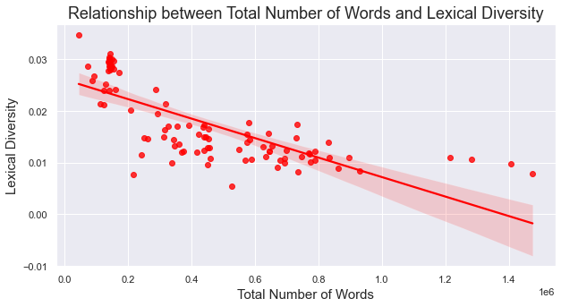

```python
# Regression plot between Total Number of Words and Lexical Diversity for the entire dataframe
# Code adopted from: https://www.geeksforgeeks.org/python-seaborn-regplot-method/

plt.figure(figsize = (10,5))
fig = sns.regplot(x = data_explore["Length"], y = data_explore["Lex_Diversity"], data = data_explore, color = "red")
plt.xlabel("Total Number of Words", fontsize = 15)
plt.ylabel("Lexical Diversity", fontsize = 15)
plt.title("Relationship between Total Number of Words and Lexical Diversity", fontsize = 18)
plt.show(fig)
```

- There is a negative correlation between Number of Words and Lexical Diversity
- As the Number of Words increases, the Lexical Diversity decreases

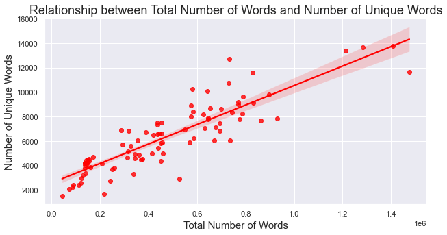

```python
# Regression plot between Total Number of Words and Number of Unique Words for the entire dataframe

plt.figure(figsize = (10,5))
fig = sns.regplot(x = data_explore["Length"], y = data_explore["Unique"], data = data_explore, color = "red")
plt.xlabel("Total Number of Words", fontsize = 15)
plt.ylabel("Number of Unique Words", fontsize = 15)
plt.title("Relationship between Total Number of Words and Number of Unique Words", fontsize = 18)
plt.show(fig)
```

- There is a positive correlation between Total Number of Words and Number of Unique Words
- As the Total Number of Words increases, the Number of Unique Words increases too

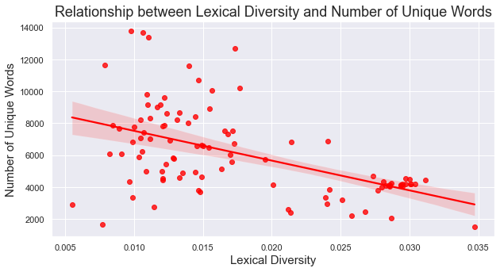

```python
# Regression plot between Number of Unique Words and Lexical Diversity for the entire dataframe

plt.figure(figsize = (10,5))
fig = sns.regplot(x = data_explore["Lex_Diversity"], y = data_explore["Unique"], data = data_explore, color = "red")
plt.xlabel("Lexical Diversity", fontsize = 15)
plt.ylabel("Number of Unique Words", fontsize = 15)
plt.title("Relationship between Lexical Diversity and Number of Unique Words", fontsize = 18)
plt.show(fig)
```

- Surprisingly, there is a negative correlation between Number of Unique Words and Lexical Diversity
- As the Number of Unique Words increases, the Lexical Diversity decreases

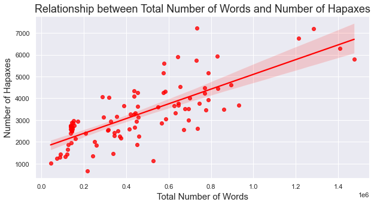

```python
# Regression plot between Total Number of Words and Number of Hapaxes for the entire dataframe

plt.figure(figsize = (10,5))
fig = sns.regplot(x = data_explore["Length"], y = data_explore["Hapaxes"], data = data_explore, color = "red")
plt.xlabel("Total Number of Words", fontsize = 15)
plt.ylabel("Number of Hapaxes", fontsize = 15)
plt.title("Relationship between Total Number of Words and Number of Hapaxes", fontsize = 18)
plt.show(fig)
```

- There is a positive correlation between Total Number of Words and Number of Hapaxes
- As the Total Number of Words increases, the Number of Hapaxes increases too

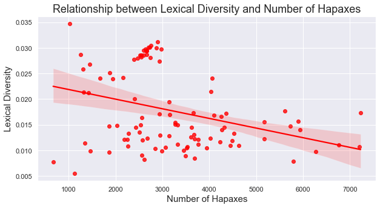

```python
# Regression plot between lexical Diversity and Number of Hapaxes for the entire dataframe

plt.figure(figsize = (10,5))
fig = sns.regplot(x = data_explore["Hapaxes"], y = data_explore["Lex_Diversity"], data = data_explore, color = "red")
plt.xlabel("Number of Hapaxes", fontsize = 15)
plt.ylabel("Lexical Diversity", fontsize = 15)
plt.title("Relationship between Lexical Diversity and Number of Hapaxes", fontsize = 18)
plt.show(fig)
```

- There is a negative correlation between Lexical Diversity and Number of Hapaxes
- As the Number of Hapaxes increases, Lexical Diversity decreases

#### Distribution plots are created to check the distribution of data across these created variables

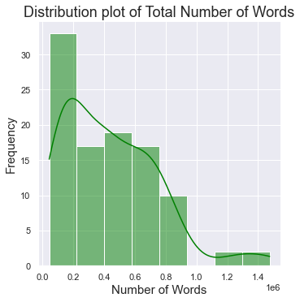

```python
# Distribution plot of Total Number of Words for the entire dataframe
# Code adopted from: https://www.geeksforgeeks.org/histograms-and-density-plots-in-python/?ref=gcse

plt.figure(figsize = (10,7))
fig = sns.displot(data = data_explore, x = data_explore["Length"], kde = True, color = "green")
plt.xlabel("Number of Words", fontsize = 15)
plt.ylabel("Frequency", fontsize = 15)
plt.title("Distribution plot of Total Number of Words", fontsize = 18)
plt.show(fig)
```

- The "Total Number of Words" variable is unsymmetrically distributed
- Data points are skewed to the right (positive skewness)

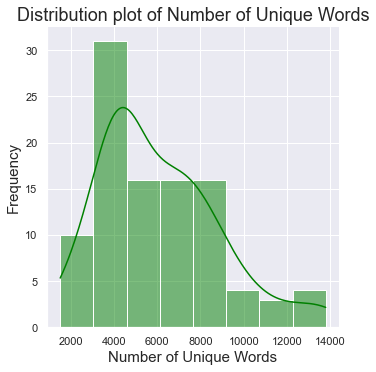

```python
# Distribution plot of Number of Unique Words for the entire dataframe

plt.figure(figsize = (10,7))
fig = sns.displot(data = data_explore, x = data_explore["Unique"], kde = True, color = "green")
plt.xlabel("Number of Unique Words", fontsize = 15)
plt.ylabel("Frequency", fontsize = 15)
plt.title("Distribution plot of Number of Unique Words", fontsize = 18)
plt.show(fig)
```

- The "Number of Unique Words" variable is also unsymmetrically distributed
- Data points are skewed to the right (positive skewness)

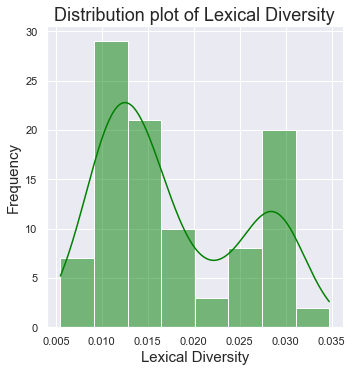

```python
# Distribution plot of Lexical Diversity for the entire dataframe

plt.figure(figsize = (10,7))
fig = sns.displot(data = data_explore, x = data_explore["Lex_Diversity"], kde = True, color = "green")
plt.xlabel("Lexical Diversity", fontsize = 15)
plt.ylabel("Frequency", fontsize = 15)
plt.title("Distribution plot of Lexical Diversity", fontsize = 18)
plt.show(fig)
```

- The "Lexical Diversity" variable has a Bimodal distribution having two peaks
- The peaks have unequal heights, hence the higher apex is the major mode, and the lower apex is the minor mode

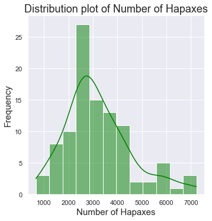

```python
# Distribution plot of Number of Hapaxes for the entire dataframe

plt.figure(figsize = (10,7))
fig = sns.displot(data = data_explore, x = data_explore["Hapaxes"], kde = True, color = "green")
plt.xlabel("Number of Hapaxes", fontsize = 15)
plt.ylabel("Frequency", fontsize = 15)
plt.title("Distribution plot of Number of Hapaxes", fontsize = 18)
plt.show(fig)
```

### 2. Frequency Distribution of Words (With and without Stopwords)

The following is done:

- Bar graph has been created to see the 10 Most frequently used Words in the dataset including Stopwords
- A new column has been created in the dataframe to store the words after removing the stopwords
- Bar graph has been created to see the 10 Most frequently used Words in the dataset after removing the stopwords

**Stopwords** are words that are so prevalent that standard tokenizers essentially ignore them, such as "a," "an," "the," "of," "in," etc.

These stopwords carry very little information as they does not convey meaning in the context the of semantics of the text

```python
# Finding the 10 most frequently used Words in the dataset including Stopwords
# Code adopted from: https://www.youtube.com/watch?v=q7AM9QjCRrI&list=PLUCTTwyv9AdUYtNeV5w-2xMX5O9cCcfkB&index=4

most_freq_words = []                         # An empty list is created to store the most frequent Words
for i in data_explore["Tokenized_word"]:     # Iterating through the column "Tokenized_word" which contains words for all text files
    for word in i:                           # Iterating through each file
        most_freq_words.append(word)         # Appending the list with words from all the text files altogether

fdist_1 = nltk.FreqDist((most_freq_words))   # "FreqDist" function will give the frequency distribution of all the words in the text

fdist_1.most_common(10)       # Finding the 10 most frequently used words in the dataset using "most_common" function
                              # It will return a list of top 10 most commonly used words with their count
```

```
[('the', 343161),
 ('of', 176019),
 ('and', 173418),
 ('to', 136203),
 ('a', 115841),
 ('in', 92120),
 ('i', 59533),
 ('that', 57733),
 ('was', 56672),
 ('he', 55879)]
```

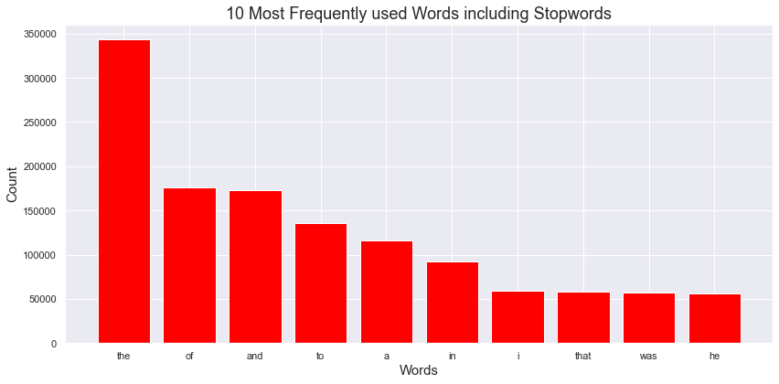

```python
# Creating a Bar Chart to show the 10 most frequently used Words in the dataset including Stopwords
# Code adopted from: https://www.tutorialspoint.com/matplotlib-make-a-frequency-histogram-from-a-list-with-tuple-elements-in-python

plt.rcParams["figure.figsize"] = [12, 6]
plt.rcParams["figure.autolayout"] = True

data = fdist_1.most_common(10)
word = []
count = []
for item in data:
    word.append(item[0])
    count.append(item[1])

plt.bar(word, count, color = "red")
plt.xlabel("Words", fontsize = 15)
plt.ylabel("Count", fontsize = 15)
plt.title("10 Most Frequently used Words including Stopwords", fontsize = 18)

plt.show()
```

- The most frequently used Words in the dataset are "the", "of", "and", "to", "a", etc.

```python
# Removing the stopwords from the text files
# Code adopted from: https://www.tutorialspoint.com/python_text_processing/python_remove_stopwords.htm#:~:text=Stopwords%20are%20the%20English%20words,this%20in%20corpus%20named%20corpus.

stop_words = set(stopwords.words("english"))             # Creating a set of unique stopwords using "stopwords.words" function
```

```python
# This function will give the list removing all the stopwords present in the nltk library for English language

def remove_stopwords(text):                                             # The function will accept the text
    no_stopwords = [word for word in text if word not in stop_words]    # Iterating through all the words that are not in stopwords
    return no_stopwords                                                 # Returning words excluding stopwords
```

```python
# Adding the column "Removed_stopwords" in the dataframe which does not contain any stopword
# Calling the function "remove_stopwords" and passing the output through lambda function to the "Tokenized_word" column

data_explore["Removed_stopwords"] = data_explore["Tokenized_word"].apply(lambda x: remove_stopwords(x))
data_explore.head()
```

| IDs | File_name | Text | Clean_text | Tokenized_word | Length | Unique | Lex_Diversity | Hapaxes | Removed_stopwords |
| --- | --- | --- | --- | --- | --- | --- | --- | --- | --- |
| 0 | 10001.txt | The Project Gutenberg EBook of Apocolocyntosis... | the project gutenberg ebook of apocolocyntosis... | [the, project, gutenberg, ebook, of, apocolocy... | 72093 | 2068 | 0.028685 | 1251 | [project, gutenberg, ebook, apocolocyntosis, l... |
| 1 | 10002.txt | Project Gutenberg's The House on the Borderlan... | project gutenbergs the house on the borderland... | [project, gutenbergs, the, house, on, the, bor... | 449590 | 5799 | 0.012898 | 2943 | [project, gutenbergs, house, borderland, willi... |
| 2 | 10003.txt | The Project Gutenberg EBook of My First Years ... | the project gutenberg ebook of my first years ... | [the, project, gutenberg, ebook, of, my, first... | 550262 | 6930 | 0.012594 | 3608 | [project, gutenberg, ebook, first, years, fren... |
| 3 | 10004.txt | The Project Gutenberg EBook of The Warriors, b... | the project gutenberg ebook of the warriors by... | [the, project, gutenberg, ebook, of, the, warr... | 438058 | 7519 | 0.017164 | 4351 | [project, gutenberg, ebook, warriors, lindsay,... |
| 4 | 10005.txt | The Project Gutenberg EBook of A Voyage to the... | the project gutenberg ebook of a voyage to the... | [the, project, gutenberg, ebook, of, a, voyage... | 625852 | 8201 | 0.013104 | 3667 | [project, gutenberg, ebook, voyage, moon, geor... |

```python
# Finding the 10 most frequently used Words in the dataset excluding Stopwords

freq_words_stop_removed = []                        # An empty list is created to store the most frequent Words excluding Stopwords
for i in data_explore["Removed_stopwords"]:         # Iterating through the column "Removed_stopwords" which contains words for all text files excluding Stopwords
    for word in i:                                  # Iterating through each text file
        if word not in stop_words:                  # If the word is not in the set of unique stopwords created above
            freq_words_stop_removed.append(word)    # Appending the list with words from all the text files altogether excluding Stopwords

fdist_2 = nltk.FreqDist((freq_words_stop_removed))  # "FreqDist" function will give the frequency distribution of all the words in the text excluding Stopwords

fdist_2.most_common(10)       # Finding the 10 most frequently used words in the dataset excluding Stopwords using "most_common" function
                              # It will return a list of top 10 most commonly used Words excluding Stopwords with their count
```

```
[('one', 16473),
 ('said', 14667),
 ('would', 12531),
 ('project', 8757),
 ('man', 8640),
 ('could', 8603),
 ('little', 8572),
 ('time', 7866),
 ('upon', 7748),
 ('work', 7746)]
```

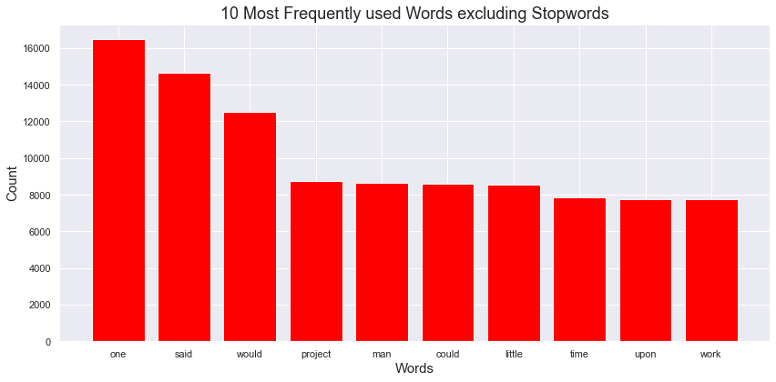

```python
# Creating a Bar Chart to show the 10 most frequently used Words in the dataset excluding Stopwords
# Code adopted from: https://www.tutorialspoint.com/matplotlib-make-a-frequency-histogram-from-a-list-with-tuple-elements-in-python

plt.rcParams["figure.figsize"] = [12, 6]
plt.rcParams["figure.autolayout"] = True

data = fdist_2.most_common(10)
word = []
count = []
for item in data:
    word.append(item[0])
    count.append(item[1])

plt.bar(word, count, color = "red")
plt.xlabel("Words", fontsize = 15)
plt.ylabel("Count", fontsize = 15)
plt.title("10 Most Frequently used Words excluding Stopwords", fontsize = 18)

plt.show()
```

- The most frequently used Words excluding the stopwords are "one", "said", "would", "project", "man", etc.

### 3. Longwords

- An assumption is made that the words greater than 10 characters are long words
- Using this, number of long words and % of long words in each text file is calculated

```python
# This function will return the number of long words present in a text
# Code adopted from: https://www.youtube.com/watch?v=q7AM9QjCRrI&list=PLUCTTwyv9AdUYtNeV5w-2xMX5O9cCcfkB&index=5

def long_words(text):                               # Function will accept text as argument
    long_word = [w for w in text if len(w) > 10]    # Looping through all the words in text, checking if word length is > 10
    n = len(long_word)                              # If length of word is > 10, it is returned by the function
    return n                                        # Number of long words is returned as function output
```

```python
# Creating a column "Long_words" containing the number of long words for every text file in the dataframe
# The function created above is called and passed to the column "Removed_stopwords" through lambda function

data_explore["Long_words"] = data_explore["Removed_stopwords"].apply(lambda x: long_words(x))
data_explore.head()
```

| IDs | File_name | Text | Clean_text | Tokenized_word | Length | Unique | Lex_Diversity | Hapaxes | Removed_stopwords | Long_words |
| --- | --- | --- | --- | --- | --- | --- | --- | --- | --- | --- |
| 0 | 10001.txt | The Project Gutenberg EBook of Apocolocyntosis... | the project gutenberg ebook of apocolocyntosis... | [the, project, gutenberg, ebook, of, apocolocy... | 72093 | 2068 | 0.028685 | 1251 | [project, gutenberg, ebook, apocolocyntosis, l... | 233 |
| 1 | 10002.txt | Project Gutenberg's The House on the Borderlan... | project gutenbergs the house on the borderland... | [project, gutenbergs, the, house, on, the, bor... | 449590 | 5799 | 0.012898 | 2943 | [project, gutenbergs, house, borderland, willi... | 1010 |
| 2 | 10003.txt | The Project Gutenberg EBook of My First Years ... | the project gutenberg ebook of my first years ... | [the, project, gutenberg, ebook, of, my, first... | 550262 | 6930 | 0.012594 | 3608 | [project, gutenberg, ebook, first, years, fren... | 1903 |
| 3 | 10004.txt | The Project Gutenberg EBook of The Warriors, b... | the project gutenberg ebook of the warriors by... | [the, project, gutenberg, ebook, of, the, warr... | 438058 | 7519 | 0.017164 | 4351 | [project, gutenberg, ebook, warriors, lindsay,... | 1738 |
| 4 | 10005.txt | The Project Gutenberg EBook of A Voyage to the... | the project gutenberg ebook of a voyage to the... | [the, project, gutenberg, ebook, of, a, voyage... | 625852 | 8201 | 0.013104 | 3667 | [project, gutenberg, ebook, voyage, moon, geor... | 2147 |

```python
# Calculating percentage of long_words in the text by dividing it with Total Number of Words in the text
# Creating a column "%_Long_words" to incorporate the percentage of long words for all text files in the dataframe
# Code adopted from: https://realpython.com/python-zip-function/

data_explore["Percent_Long_words"] = [100*(x/y) for x, y in zip(data_explore["Long_words"], data_explore["Length"])]
data_explore.head()
```

| IDs | File_name | Text | Clean_text | Tokenized_word | Length | Unique | Lex_Diversity | Hapaxes | Removed_stopwords | Long_words | Percent_Long_words |
| --- | --- | --- | --- | --- | --- | --- | --- | --- | --- | --- | --- |
| 0 | 10001.txt | The Project Gutenberg EBook of Apocolocyntosis... | the project gutenberg ebook of apocolocyntosis... | [the, project, gutenberg, ebook, of, apocolocy... | 72093 | 2068 | 0.028685 | 1251 | [project, gutenberg, ebook, apocolocyntosis, l... | 233 | 0.323194 |
| 1 | 10002.txt | Project Gutenberg's The House on the Borderlan... | project gutenbergs the house on the borderland... | [project, gutenbergs, the, house, on, the, bor... | 449590 | 5799 | 0.012898 | 2943 | [project, gutenbergs, house, borderland, willi... | 1010 | 0.224649 |
| 2 | 10003.txt | The Project Gutenberg EBook of My First Years ... | the project gutenberg ebook of my first years ... | [the, project, gutenberg, ebook, of, my, first... | 550262 | 6930 | 0.012594 | 3608 | [project, gutenberg, ebook, first, years, fren... | 1903 | 0.345835 |
| 3 | 10004.txt | The Project Gutenberg EBook of The Warriors, b... | the project gutenberg ebook of the warriors by... | [the, project, gutenberg, ebook, of, the, warr... | 438058 | 7519 | 0.017164 | 4351 | [project, gutenberg, ebook, warriors, lindsay,... | 1738 | 0.396751 |
| 4 | 10005.txt | The Project Gutenberg EBook of A Voyage to the... | the project gutenberg ebook of a voyage to the... | [the, project, gutenberg, ebook, of, a, voyage... | 625852 | 8201 | 0.013104 | 3667 | [project, gutenberg, ebook, voyage, moon, geor... | 2147 | 0.343052 |

### 4. Bigrams

- Bigrams are created for each text file in the dataframe

**Bigrams** are a sequence of two adjacent words from a string of text

```python
# This function will create bigrams of words from the text file

def create_bigrams(text):                          # Function will accept the text
    bigram_words = [word for word in text]         # The words will be passed into a list through iteration
    bigrams = list(nltk.bigrams(bigram_words))     # "bigrams" function of nltk library is used to create lists of word bigrams
    return bigrams                                 # bigrams of words will be returned as a list
```

```python
# Creating a new column "Bigrams" to store bigrams of words for each text file

data_explore["Bigrams"] = data_explore["Removed_stopwords"].apply(lambda x: create_bigrams(x))
data_explore.head()
```

| IDs | File_name | Text | Clean_text | Tokenized_word | Length | Unique | Lex_Diversity | Hapaxes | Removed_stopwords | Long_words | Percent_Long_words | Bigrams |
| --- | --- | --- | --- | --- | --- | --- | --- | --- | --- | --- | --- | --- |
| 0 | 10001.txt | The Project Gutenberg EBook of Apocolocyntosis... | the project gutenberg ebook of apocolocyntosis... | [the, project, gutenberg, ebook, of, apocolocy... | 72093 | 2068 | 0.028685 | 1251 | [project, gutenberg, ebook, apocolocyntosis, l... | 233 | 0.323194 | [(project, gutenberg), (gutenberg, ebook), (eb... |
| 1 | 10002.txt | Project Gutenberg's The House on the Borderlan... | project gutenbergs the house on the borderland... | [project, gutenbergs, the, house, on, the, bor... | 449590 | 5799 | 0.012898 | 2943 | [project, gutenbergs, house, borderland, willi... | 1010 | 0.224649 | [(project, gutenbergs), (gutenbergs, house), (... |
| 2 | 10003.txt | The Project Gutenberg EBook of My First Years ... | the project gutenberg ebook of my first years ... | [the, project, gutenberg, ebook, of, my, first... | 550262 | 6930 | 0.012594 | 3608 | [project, gutenberg, ebook, first, years, fren... | 1903 | 0.345835 | [(project, gutenberg), (gutenberg, ebook), (eb... |
| 3 | 10004.txt | The Project Gutenberg EBook of The Warriors, b... | the project gutenberg ebook of the warriors by... | [the, project, gutenberg, ebook, of, the, warr... | 438058 | 7519 | 0.017164 | 4351 | [project, gutenberg, ebook, warriors, lindsay,... | 1738 | 0.396751 | [(project, gutenberg), (gutenberg, ebook), (eb... |
| 4 | 10005.txt | The Project Gutenberg EBook of A Voyage to the... | the project gutenberg ebook of a voyage to the... | [the, project, gutenberg, ebook, of, a, voyage... | 625852 | 8201 | 0.013104 | 3667 | [project, gutenberg, ebook, voyage, moon, geor... | 2147 | 0.343052 | [(project, gutenberg), (gutenberg, ebook), (eb... |

### 5. Trigrams

- Trigrams are created for each text file in the dataframe

**Trigrams** are a sequence of three adjacent words from a string of text

```python
# This function will create trigrams of words from the text file

def create_trigrams(text):                          # Function will accept the text
    trigram_words = [word for word in text]         # The words will be passed into a list through iteration
    trigrams = list(nltk.trigrams(trigram_words))   # "trigrams" function of nltk library is used to create lists of trigrams
    return trigrams                                 # trigrams of words will be returned as a list
```

```python
# Creating a new column "Trigrams" to store trigrams of words for each text file

data_explore["Trigrams"] = data_explore["Removed_stopwords"].apply(lambda x: create_trigrams(x))
data_explore.head()
```

| IDs | File_name | Text | Clean_text | Tokenized_word | Length | Unique | Lex_Diversity | Hapaxes | Removed_stopwords | Long_words | Percent_Long_words | Bigrams | Trigrams |
| --- | --- | --- | --- | --- | --- | --- | --- | --- | --- | --- | --- | --- | --- |
| 0 | 10001.txt | The Project Gutenberg EBook of Apocolocyntosis... | the project gutenberg ebook of apocolocyntosis... | [the, project, gutenberg, ebook, of, apocolocy... | 72093 | 2068 | 0.028685 | 1251 | [project, gutenberg, ebook, apocolocyntosis, l... | 233 | 0.323194 | [(project, gutenberg), (gutenberg, ebook), (eb... | [(project, gutenberg, ebook), (gutenberg, eboo... |
| 1 | 10002.txt | Project Gutenberg's The House on the Borderlan... | project gutenbergs the house on the borderland... | [project, gutenbergs, the, house, on, the, bor... | 449590 | 5799 | 0.012898 | 2943 | [project, gutenbergs, house, borderland, willi... | 1010 | 0.224649 | [(project, gutenbergs), (gutenbergs, house), (... | [(project, gutenbergs, house), (gutenbergs, ho... |
| 2 | 10003.txt | The Project Gutenberg EBook of My First Years ... | the project gutenberg ebook of my first years ... | [the, project, gutenberg, ebook, of, my, first... | 550262 | 6930 | 0.012594 | 3608 | [project, gutenberg, ebook, first, years, fren... | 1903 | 0.345835 | [(project, gutenberg), (gutenberg, ebook), (eb... | [(project, gutenberg, ebook), (gutenberg, eboo... |
| 3 | 10004.txt | The Project Gutenberg EBook of The Warriors, b... | the project gutenberg ebook of the warriors by... | [the, project, gutenberg, ebook, of, the, warr... | 438058 | 7519 | 0.017164 | 4351 | [project, gutenberg, ebook, warriors, lindsay,... | 1738 | 0.396751 | [(project, gutenberg), (gutenberg, ebook), (eb... | [(project, gutenberg, ebook), (gutenberg, eboo... |
| 4 | 10005.txt | The Project Gutenberg EBook of A Voyage to the... | the project gutenberg ebook of a voyage to the... | [the, project, gutenberg, ebook, of, a, voyage... | 625852 | 8201 | 0.013104 | 3667 | [project, gutenberg, ebook, voyage, moon, geor... | 2147 | 0.343052 | [(project, gutenberg), (gutenberg, ebook), (eb... | [(project, gutenberg, ebook), (gutenberg, eboo... |

### 6. POS Tagging

- POS tags have been created for each text file
- Number of unique POS tags for each file have been calculated

**POS Tagging** is a process of labelling words with their type (Verb, Noun, Adjective, Adverb, etc).

It is a necessary step before using a wordnet to lemmatize text data.

```python
# function "pos_tag" from nltk library is used to create POS tags for each text file
# Creating a new column "POS_tags" to store the POS tags for each text file in the dataframe

data_explore["POS_tags"] = data_explore["Removed_stopwords"].apply(nltk.tag.pos_tag)
data_explore.head()
```

| IDs | File_name | Text | Clean_text | Tokenized_word | Length | Unique | Lex_Diversity | Hapaxes | Removed_stopwords | Long_words | Percent_Long_words | Bigrams | Trigrams | POS_tags |
| --- | --- | --- | --- | --- | --- | --- | --- | --- | --- | --- | --- | --- | --- | --- |
| 0 | 10001.txt | The Project Gutenberg EBook of Apocolocyntosis... | the project gutenberg ebook of apocolocyntosis... | [the, project, gutenberg, ebook, of, apocolocy... | 72093 | 2068 | 0.028685 | 1251 | [project, gutenberg, ebook, apocolocyntosis, l... | 233 | 0.323194 | [(project, gutenberg), (gutenberg, ebook), (eb... | [(project, gutenberg, ebook), (gutenberg, eboo... | [(project, NN), (gutenberg, NN), (ebook, NN), ... |
| 1 | 10002.txt | Project Gutenberg's The House on the Borderlan... | project gutenbergs the house on the borderland... | [project, gutenbergs, the, house, on, the, bor... | 449590 | 5799 | 0.012898 | 2943 | [project, gutenbergs, house, borderland, willi... | 1010 | 0.224649 | [(project, gutenbergs), (gutenbergs, house), (... | [(project, gutenbergs, house), (gutenbergs, ho... | [(project, NN), (gutenbergs, NN), (house, NN),... |
| 2 | 10003.txt | The Project Gutenberg EBook of My First Years ... | the project gutenberg ebook of my first years ... | [the, project, gutenberg, ebook, of, my, first... | 550262 | 6930 | 0.012594 | 3608 | [project, gutenberg, ebook, first, years, fren... | 1903 | 0.345835 | [(project, gutenberg), (gutenberg, ebook), (eb... | [(project, gutenberg, ebook), (gutenberg, eboo... | [(project, NN), (gutenberg, NN), (ebook, NN), ... |
| 3 | 10004.txt | The Project Gutenberg EBook of The Warriors, b... | the project gutenberg ebook of the warriors by... | [the, project, gutenberg, ebook, of, the, warr... | 438058 | 7519 | 0.017164 | 4351 | [project, gutenberg, ebook, warriors, lindsay,... | 1738 | 0.396751 | [(project, gutenberg), (gutenberg, ebook), (eb... | [(project, gutenberg, ebook), (gutenberg, eboo... | [(project, NN), (gutenberg, NN), (ebook, NN), ... |
| 4 | 10005.txt | The Project Gutenberg EBook of A Voyage to the... | the project gutenberg ebook of a voyage to the... | [the, project, gutenberg, ebook, of, a, voyage... | 625852 | 8201 | 0.013104 | 3667 | [project, gutenberg, ebook, voyage, moon, geor... | 2147 | 0.343052 | [(project, gutenberg), (gutenberg, ebook), (eb... | [(project, gutenberg, ebook), (gutenberg, eboo... | [(project, NN), (gutenberg, NN), (ebook, NN), ... |

```python
# Exploring the POS tags for the first book in the dataframe (Printing first 10 POS tags)

print(data_explore["POS_tags"].iloc[0][:10])
```

```
[('project', 'NN'), ('gutenberg', 'NN'), ('ebook', 'NN'), ('apocolocyntosis', 'NN'), ('lucius', 'NN'), ('seneca', 'NN'), ('ebook', 'NN'), ('use', 'NN'), ('anyone', 'NN'), ('anywhere', 'RB')]
```

nltk has the following POS_tags:

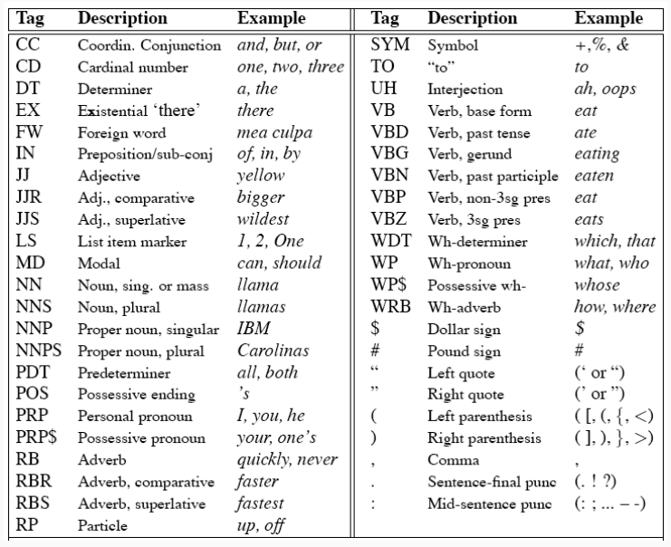

Source: https://snlp2018.github.io/slides/pos-tagging-handout.pdf

```python
# This function will return the number of unique POS tags from a text file
# Code adopted from the module's exercises

def unique_pos_tags(text):                     # Function will accept text as argument
    just_the_tags = [tu[1] for tu in text]     # Iterating through the text, and getting second elememts (Tags) of the tuple
    n_unique_tags = len(set(just_the_tags))    # Finding the length of the unique tags present in the dataset
    return n_unique_tags                       # Function will return the number of unique POS tags
```

```python
# Creating a new column "Unique_POS" to store the number of unique POS tags for each text file in the dataframe

data_explore["Unique_POS"] = [unique_pos_tags(i) for i in data_explore["POS_tags"]]   # Iterating through all the POS_tags
data_explore.head()
```

| IDs | File_name | Text | Clean_text | Tokenized_word | Length | Unique | Lex_Diversity | Hapaxes | Removed_stopwords | Long_words | Percent_Long_words | Bigrams | Trigrams | POS_tags | Unique_POS |
| --- | --- | --- | --- | --- | --- | --- | --- | --- | --- | --- | --- | --- | --- | --- | --- |
| 0 | 10001.txt | The Project Gutenberg EBook of Apocolocyntosis... | the project gutenberg ebook of apocolocyntosis... | [the, project, gutenberg, ebook, of, apocolocy... | 72093 | 2068 | 0.028685 | 1251 | [project, gutenberg, ebook, apocolocyntosis, l... | 233 | 0.323194 | [(project, gutenberg), (gutenberg, ebook), (eb... | [(project, gutenberg, ebook), (gutenberg, eboo... | [(project, NN), (gutenberg, NN), (ebook, NN), ... | 26 |
| 1 | 10002.txt | Project Gutenberg's The House on the Borderlan... | project gutenbergs the house on the borderland... | [project, gutenbergs, the, house, on, the, bor... | 449590 | 5799 | 0.012898 | 2943 | [project, gutenbergs, house, borderland, willi... | 1010 | 0.224649 | [(project, gutenbergs), (gutenbergs, house), (... | [(project, gutenbergs, house), (gutenbergs, ho... | [(project, NN), (gutenbergs, NN), (house, NN),... | 27 |
| 2 | 10003.txt | The Project Gutenberg EBook of My First Years ... | the project gutenberg ebook of my first years ... | [the, project, gutenberg, ebook, of, my, first... | 550262 | 6930 | 0.012594 | 3608 | [project, gutenberg, ebook, first, years, fren... | 1903 | 0.345835 | [(project, gutenberg), (gutenberg, ebook), (eb... | [(project, gutenberg, ebook), (gutenberg, eboo... | [(project, NN), (gutenberg, NN), (ebook, NN), ... | 33 |
| 3 | 10004.txt | The Project Gutenberg EBook of The Warriors, b... | the project gutenberg ebook of the warriors by... | [the, project, gutenberg, ebook, of, the, warr... | 438058 | 7519 | 0.017164 | 4351 | [project, gutenberg, ebook, warriors, lindsay,... | 1738 | 0.396751 | [(project, gutenberg), (gutenberg, ebook), (eb... | [(project, gutenberg, ebook), (gutenberg, eboo... | [(project, NN), (gutenberg, NN), (ebook, NN), ... | 29 |
| 4 | 10005.txt | The Project Gutenberg EBook of A Voyage to the... | the project gutenberg ebook of a voyage to the... | [the, project, gutenberg, ebook, of, a, voyage... | 625852 | 8201 | 0.013104 | 3667 | [project, gutenberg, ebook, voyage, moon, geor... | 2147 | 0.343052 | [(project, gutenberg), (gutenberg, ebook), (eb... | [(project, gutenberg, ebook), (gutenberg, eboo... | [(project, NN), (gutenberg, NN), (ebook, NN), ... | 30 |

### 7. Word Cloud

- A Word Cloud has been generated for a selected book from the dataframe

A **Word Cloud** is a visual representation of text data in the form of tags, which are typically single words whose importance is visualised by way of their size and color.

A Word Cloud is an good option to help visually interpret text and is useful in quickly gaining insight into the most occuring words in a given text, by visualizing the word frequency in the text.

```python
# This function will generate the word cloud for any given book in the dataframe
# Code adopted from:
  # 1. https://neptune.ai/blog/exploratory-data-analysis-natural-language-processing-tools
  # 2. https://github.com/MengyaoHuang/Data-Manipulation-and-Analysis/blob/master/Natural%20Language%20Processing%20for%20Project%20Gutenberg.ipynb

def book_word_cloud(text):                                  # Function will accept the text as argument

    words_in_cloud = " ".join(word for word in text)        # Iterating through the text and joining the words
    stopwords = set(STOPWORDS)                              # Creating a set of unique stopwords to exclude from the word cloud
    word_cloud = WordCloud(stopwords = stopwords, background_color = "white").generate(words_in_cloud)    # Generating word cloud
    plt.figure(figsize = (10,8))
    plt.imshow(word_cloud, interpolation = "bilinear")
    plt.title("Word Cloud of the selected Book", size = 20, fontweight = "bold")
    plt.axis("off")
    plt.show()
```

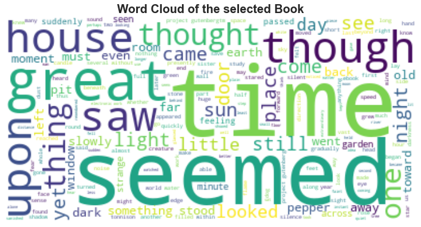

```python
# Generating the word cloud for book2

book2 = data_explore["Removed_stopwords"].iloc[1]    # Accessing book2 by its location to generate its word cloud

book_word_cloud(book2)                               # Calling the function to generate book2 word cloud
```

- The most frequent words in book2 are "time", "seemed", "though", "great", "saw", "upon", "house", etc.

### 8. Stemming and Lemmatization

**Stemming and Lemmarization** are processes of word normalisation, removing conflations and converting each word to its base form.

It is a pre-processing stage that is recommended to take place before any automated analysis or process, because without it most Machine Learning algorithms would struggle to find any patterns in the text being analysed since there will be too many variations of each word in the text and therefore too much noise.

#### 8.1 Stemming

**Stemming** is the process of cutting off letters until the user ends up with some base form of the word.

The Stemming algorithms usually remove comon suffixes and prefixes, along with definite articles in languages that have them attached to the word.

```python
# Porter Stemmer is used to perform stemming of words

porter = PorterStemmer()        # Creating an object "porter" of PorterStemmer
```

```python
# Creating a new column "Stemmed" in the dataframe to store stemmed words
# "stem()"" function from nltk library is used to perform stemming on words from the text
# Code adopted from the module's lectures/exercises

data_explore["Stemmed"] = data_explore["Removed_stopwords"].apply(lambda x: [porter.stem(word) for word in x])
data_explore.head()
```

| IDs | File_name | Text | Clean_text | Tokenized_word | Length | Unique | Lex_Diversity | Hapaxes | Removed_stopwords | Long_words | Percent_Long_words | Bigrams | Trigrams | POS_tags | Unique_POS | Stemmed |
| --- | --- | --- | --- | --- | --- | --- | --- | --- | --- | --- | --- | --- | --- | --- | --- | --- |
| 0 | 10001.txt | The Project Gutenberg EBook of Apocolocyntosis... | the project gutenberg ebook of apocolocyntosis... | [the, project, gutenberg, ebook, of, apocolocy... | 72093 | 2068 | 0.028685 | 1251 | [project, gutenberg, ebook, apocolocyntosis, l... | 233 | 0.323194 | [(project, gutenberg), (gutenberg, ebook), (eb... | [(project, gutenberg, ebook), (gutenberg, eboo... | [(project, NN), (gutenberg, NN), (ebook, NN), ... | 26 | [project, gutenberg, ebook, apocolocyntosi, lu... |
| 1 | 10002.txt | Project Gutenberg's The House on the Borderlan... | project gutenbergs the house on the borderland... | [project, gutenbergs, the, house, on, the, bor... | 449590 | 5799 | 0.012898 | 2943 | [project, gutenbergs, house, borderland, willi... | 1010 | 0.224649 | [(project, gutenbergs), (gutenbergs, house), (... | [(project, gutenbergs, house), (gutenbergs, ho... | [(project, NN), (gutenbergs, NN), (house, NN),... | 27 | [project, gutenberg, hous, borderland, william... |
| 2 | 10003.txt | The Project Gutenberg EBook of My First Years ... | the project gutenberg ebook of my first years ... | [the, project, gutenberg, ebook, of, my, first... | 550262 | 6930 | 0.012594 | 3608 | [project, gutenberg, ebook, first, years, fren... | 1903 | 0.345835 | [(project, gutenberg), (gutenberg, ebook), (eb... | [(project, gutenberg, ebook), (gutenberg, eboo... | [(project, NN), (gutenberg, NN), (ebook, NN), ... | 33 | [project, gutenberg, ebook, first, year, frenc... |
| 3 | 10004.txt | The Project Gutenberg EBook of The Warriors, b... | the project gutenberg ebook of the warriors by... | [the, project, gutenberg, ebook, of, the, warr... | 438058 | 7519 | 0.017164 | 4351 | [project, gutenberg, ebook, warriors, lindsay,... | 1738 | 0.396751 | [(project, gutenberg), (gutenberg, ebook), (eb... | [(project, gutenberg, ebook), (gutenberg, eboo... | [(project, NN), (gutenberg, NN), (ebook, NN), ... | 29 | [project, gutenberg, ebook, warrior, lindsay, ... |
| 4 | 10005.txt | The Project Gutenberg EBook of A Voyage to the... | the project gutenberg ebook of a voyage to the... | [the, project, gutenberg, ebook, of, a, voyage... | 625852 | 8201 | 0.013104 | 3667 | [project, gutenberg, ebook, voyage, moon, geor... | 2147 | 0.343052 | [(project, gutenberg), (gutenberg, ebook), (eb... | [(project, gutenberg, ebook), (gutenberg, eboo... | [(project, NN), (gutenberg, NN), (ebook, NN), ... | 30 | [project, gutenberg, ebook, voyag, moon, georg... |

#### 8.2 Lemmatization

**Lemmatisation** on the other hand, will produce the actual words because it converts the original words into their linguistic base, removing any indication of variation based on time or quantity.

This means that the results will have the same basic meaning just in its root form.

```python
# WordNetLemmatizer is used to perform lemmatization of words

lemmer = WordNetLemmatizer()      # Creating an object "lemmer" of WordNetLemmatizer
```

- The wordnet is used because the lemmatizer relies on knowing, to what part of speech words belong, to lemmatize according to the filemap.
- So the wordnet lemmatizer only works for nouns, verbs, adjectives and adverbs.

```python
display(wn._FILEMAP)
```

```
{'a': 'adj', 'r': 'adv', 'n': 'noun', 'v': 'verb'}
```

- This information has to be passed to lemmatizer for each word as the key in this filemap
- However there are two issues when using POS_tag function:
  - There are many more tags than the lemmatizer uses
  - And the tags have to be converted to one of the single character keys in the file map

```python
# As a solution to this, a function is defined to make that conversion
# Since there are 4 possibilities, the get method will allow to define a default value that is chosen as a Noun,
# which is actually the default value for the wordnet lemmatizer if the tag is not passed
# Code adopted from the module's lectures/exercises

def get_file_key(pos_tag):
    return {"NN":"n",
            "VB":"v",
            "RB":"r",
            "JJ":"a"
            }.get(pos_tag[:2],"n")
```

```python
# Creating a new column "Lemmatized" in the dataframe to store lemmatized words
# "lemmatize()"" function from nltk library is used to perform lemmatization
# Code adopted from the module's lectures/exercises

data_explore["Lemmatized"] = data_explore["POS_tags"].apply(lambda x: [lemmer.lemmatize(word, get_file_key(tag)) for word, tag in x])

data_explore.head()
```

| IDs | File_name | Text | Clean_text | Tokenized_word | Length | Unique | Lex_Diversity | Hapaxes | Removed_stopwords | Long_words | Percent_Long_words | Bigrams | Trigrams | POS_tags | Unique_POS | Stemmed | Lemmatized |
| --- | --- | --- | --- | --- | --- | --- | --- | --- | --- | --- | --- | --- | --- | --- | --- | --- | --- |
| 0 | 10001.txt | The Project Gutenberg EBook of Apocolocyntosis... | the project gutenberg ebook of apocolocyntosis... | [the, project, gutenberg, ebook, of, apocolocy... | 72093 | 2068 | 0.028685 | 1251 | [project, gutenberg, ebook, apocolocyntosis, l... | 233 | 0.323194 | [(project, gutenberg), (gutenberg, ebook), (eb... | [(project, gutenberg, ebook), (gutenberg, eboo... | [(project, NN), (gutenberg, NN), (ebook, NN), ... | 26 | [project, gutenberg, ebook, apocolocyntosi, lu... | [project, gutenberg, ebook, apocolocyntosis, l... |
| 1 | 10002.txt | Project Gutenberg's The House on the Borderlan... | project gutenbergs the house on the borderland... | [project, gutenbergs, the, house, on, the, bor... | 449590 | 5799 | 0.012898 | 2943 | [project, gutenbergs, house, borderland, willi... | 1010 | 0.224649 | [(project, gutenbergs), (gutenbergs, house), (... | [(project, gutenbergs, house), (gutenbergs, ho... | [(project, NN), (gutenbergs, NN), (house, NN),... | 27 | [project, gutenberg, hous, borderland, william... | [project, gutenberg, house, borderland, willia... |
| 2 | 10003.txt | The Project Gutenberg EBook of My First Years ... | the project gutenberg ebook of my first years ... | [the, project, gutenberg, ebook, of, my, first... | 550262 | 6930 | 0.012594 | 3608 | [project, gutenberg, ebook, first, years, fren... | 1903 | 0.345835 | [(project, gutenberg), (gutenberg, ebook), (eb... | [(project, gutenberg, ebook), (gutenberg, eboo... | [(project, NN), (gutenberg, NN), (ebook, NN), ... | 33 | [project, gutenberg, ebook, first, year, frenc... | [project, gutenberg, ebook, first, year, frenc... |
| 3 | 10004.txt | The Project Gutenberg EBook of The Warriors, b... | the project gutenberg ebook of the warriors by... | [the, project, gutenberg, ebook, of, the, warr... | 438058 | 7519 | 0.017164 | 4351 | [project, gutenberg, ebook, warriors, lindsay,... | 1738 | 0.396751 | [(project, gutenberg), (gutenberg, ebook), (eb... | [(project, gutenberg, ebook), (gutenberg, eboo... | [(project, NN), (gutenberg, NN), (ebook, NN), ... | 29 | [project, gutenberg, ebook, warrior, lindsay, ... | [project, gutenberg, ebook, warrior, lindsay, ... |
| 4 | 10005.txt | The Project Gutenberg EBook of A Voyage to the... | the project gutenberg ebook of a voyage to the... | [the, project, gutenberg, ebook, of, a, voyage... | 625852 | 8201 | 0.013104 | 3667 | [project, gutenberg, ebook, voyage, moon, geor... | 2147 | 0.343052 | [(project, gutenberg), (gutenberg, ebook), (eb... | [(project, gutenberg, ebook), (gutenberg, eboo... | [(project, NN), (gutenberg, NN), (ebook, NN), ... | 30 | [project, gutenberg, ebook, voyag, moon, georg... | [project, gutenberg, ebook, voyage, moon, geor... |

### 9. Wordnet

The following are generated using wordnet:

- Synsets
- Lemmas
- Hyponyms
- Hypernyms

**Wordnet** is a network of words.

Words are connected by a number of grammatical and semantical rules, synonymy being the main one, where words that mean the same thing are connected and grouped together.

In a wordnet, these groups are called **Synsets**.

The words and synsets are furthermore connected by connections called **Hyponyms**

As wordnet is a tree, one can get the node above a word with **Hypernyms** and all the branches below a word with **Hyponyms**

**Lemma** is a form of a word that appears as an entry in a dictionary and is used to represent all the other possible forms.

Since "said" and "man" were among the most frequent words in the dataset, these are explored further using wordnet

```python
# Code adopted from the module's exercise

syn1 = wn.synsets("said")[0]                     # Defining a variable "syn1" to store the first synset of word "said"
syn2 = wn.synsets("man")[0]                      # Defining a variable "syn2" to store the first synset of word "man"

for syns in [syn1,syn2]:                         # Iterating through the synsets of the given words
    print("Exploring", syns.name())              # Printing the Name of the synset
    print("Definition:",syns.definition())       # Printing the Definition of the synset
    print("Examples:",syns.examples())           # Printing the Examples of the synset
    print("Hyernyms:",syns.hypernyms())          # Printing the Hypernyms of the synset
    print("Hyponyms:", syns.hyponyms())          # Printing the Hyponyms of the synset
    print("Lemmas:", syns.lemmas())              # Printing the Lemmas of the synset
    print("\n")                                  # A new line to separate the two synsets
```

```
Exploring state.v.01
Definition: express in words
Examples: ['He said that he wanted to marry her', 'tell me what is bothering you', 'state your opinion', 'state your name']
Hyernyms: [Synset('express.v.02')]
Hyponyms: [Synset('add.v.02'), Synset('announce.v.02'), Synset('answer.v.01'), Synset('articulate.v.05'), Synset('declare.v.01'), Synset('declare.v.07'), Synset('explain.v.02'), Synset('get_out.v.04'), Synset('give.v.04'), Synset('misstate.v.01'), Synset('note.v.01'), Synset('precede.v.05'), Synset(…
Lemmas: [Lemma('state.v.01.state'), Lemma('state.v.01.say'), Lemma('state.v.01.tell')]


Exploring man.n.01
Definition: an adult person who is male (as opposed to a woman)
Examples: ['there were two women and six men on the bus']
Hyernyms: [Synset('adult.n.01'), Synset('male.n.02')]
Hyponyms: [Synset('adonis.n.01'), Synset('babu.n.01'), Synset('bachelor.n.01'), Synset('bey.n.01'), Synset('black_man.n.01'), Synset('boy.n.02'), Synset('boyfriend.n.01'), Synset('bull.n.02'), Synset('dandy.n.01'), Synset('ejaculator.n.01'), Synset('esquire.n.02'), Synset('eunuch.n.01'), Synset('ex-…
Lemmas: [Lemma('man.n.01.man'), Lemma('man.n.01.adult_male')]
```

### 10. Sentiment Analysis

- A new dataframe containing the cleaned text has been created from previous dataframe to perform Sentiment Analysis
- The text has been lemmatized and polarity scores for Positive, Negative and Neutral sentiments have been calculated using Sentiment Intensity Analyzer

**Sentiment Analysis** is used for identifying, extracting, and quantifying sentimental information from the text.

There are multiple types of sentiment analysis and the basic one is to classify the polarity of the text document (Negative, Positive or Neutral).

```python
# A new dataframe "text_sentiment" is created by copying only the File name and Clean text from the "data_explore" dataframe
# This is because only the "Clean_text" column is required to perform Sentiment Analysis of text

text_sentiment = data_explore[["File_name", "Clean_text"]].copy()
text_sentiment.head()
```

| IDs | File_name | Clean_text |
| --- | --- | --- |
| 0 | 10001.txt | the project gutenberg ebook of apocolocyntosis... |
| 1 | 10002.txt | project gutenbergs the house on the borderland... |
| 2 | 10003.txt | the project gutenberg ebook of my first years ... |
| 3 | 10004.txt | the project gutenberg ebook of the warriors by... |
| 4 | 10005.txt | the project gutenberg ebook of a voyage to the... |

```python
# Applying the "lemmatize" function on the clean text to generate the lemmatized string of words
# Creating a new column "Sentiment" to store the lemmatized string of words

text_sentiment["Lemmatized_sentiment"] = text_sentiment["Clean_text"].apply(lambda x: lemmer.lemmatize(x))
text_sentiment.head()
```

| IDs | File_name | Clean_text | Lemmatized_sentiment |
| --- | --- | --- | --- |
| 0 | 10001.txt | the project gutenberg ebook of apocolocyntosis... | the project gutenberg ebook of apocolocyntosis... |
| 1 | 10002.txt | project gutenbergs the house on the borderland... | project gutenbergs the house on the borderland... |
| 2 | 10003.txt | the project gutenberg ebook of my first years ... | the project gutenberg ebook of my first years ... |
| 3 | 10004.txt | the project gutenberg ebook of the warriors by... | the project gutenberg ebook of the warriors by... |
| 4 | 10005.txt | the project gutenberg ebook of a voyage to the... | the project gutenberg ebook of a voyage to the... |

```python
# Sentiment Intensity Analyzer is used to perform Sentiment Analysis

sentiment_intensity = SentimentIntensityAnalyzer()    # Creating an object "sentiment_intensity" of SentimentIntensityAnalyzer
```

```python
# Creating three columns in the dataframe each showing the Positive, Negative and Neutral polarity scores for text files
# "polarity_scores" function is used to calculate the 3 polarity scores for each text file
# Code adopted from: https://towardsdatascience.com/sentimental-analysis-using-vader-a3415fef7664

text_sentiment["Positive"] = [sentiment_intensity.polarity_scores(i)["pos"] for i in text_sentiment["Lemmatized_sentiment"]]
text_sentiment["Negative"] = [sentiment_intensity.polarity_scores(i)["neg"] for i in text_sentiment["Lemmatized_sentiment"]]
text_sentiment["Neutral"] = [sentiment_intensity.polarity_scores(i)["neu"] for i in text_sentiment["Lemmatized_sentiment"]]

text_sentiment.head()
```

| IDs | File_name | Clean_text | Lemmatized_sentiment | Positive | Negative | Neutral |
| --- | --- | --- | --- | --- | --- | --- |
| 0 | 10001.txt | the project gutenberg ebook of apocolocyntosis... | the project gutenberg ebook of apocolocyntosis... | 0.116 | 0.089 | 0.795 |
| 1 | 10002.txt | project gutenbergs the house on the borderland... | project gutenbergs the house on the borderland... | 0.089 | 0.100 | 0.811 |
| 2 | 10003.txt | the project gutenberg ebook of my first years ... | the project gutenberg ebook of my first years ... | 0.144 | 0.061 | 0.795 |
| 3 | 10004.txt | the project gutenberg ebook of the warriors by... | the project gutenberg ebook of the warriors by... | 0.174 | 0.065 | 0.761 |
| 4 | 10005.txt | the project gutenberg ebook of a voyage to the... | the project gutenberg ebook of a voyage to the... | 0.129 | 0.070 | 0.801 |

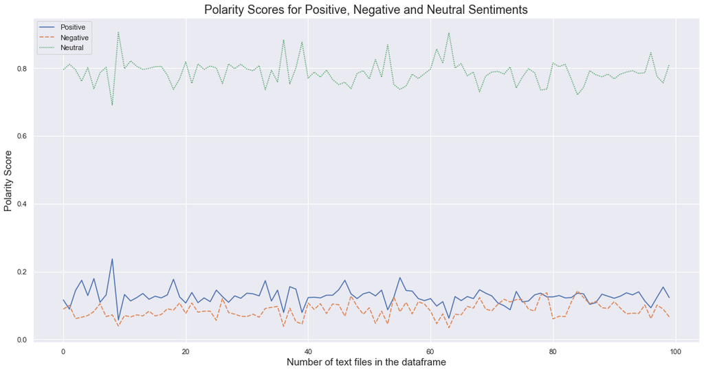

```python
# Creating a line graph showing Positive, Negative and Neutral polarity scores for the text files in the dataframe

plt.figure(figsize = (15,8))
plt.xlabel("Number of text files in the dataframe", fontsize = 15)
plt.ylabel("Polarity Score", fontsize = 15)
plt.title("Polarity Scores for Positive, Negative and Neutral Sentiments", fontsize = 18)

sns.lineplot(data = text_sentiment)              # "lineplot" function is used from seaborn library
```

- Overall values of Neutral polarity scores are quite high
- Overall values of Positive and Negative polarity scores are quite low

#### Based on the Exploratory Data Analysis, following questions are proposed to be answered in the next section:

**Question 1**: Who are the Authors and their Books with the Highest and Lowest Lexical Diversity?

**Question 2**: Who are the Authors with the most Positive, Negative and Neutral attitude towards writing their books measured using Polarity Scores?

**Question 3**: Who are the Authors having the highest and lowest percentage of long words (words>10 characters) in their books? And what effect does the Percentage of Long Words have on Lexical Diversity?

**Question 4**: Which Author has written the most number of books?

**Question 5**: Who are the Authors having the most and least number of Unique POS tags in their books?

## Section 3: Descriptive Analytics

- In this section, the dataset has been interrogated using Descriptive Analytics
- Five questions that were framed in the previous section, have been answered using Descriptive Analytics.
- The questions, their justification about why they are interesting, and their answers are presented in this section

### Question 1: Who are the Authors and their Books with the highest Lexical Diversity and lowest Lexical Diversity?

- The Author and Book are identified using the ID that has the books with the highest and lowest Lexical Diversities

### Justification of why this question is interesting

- This will provide insights about the Authors and their Books with the highest and lowest Lexical Richness
- Lexical diversity can assist in assessing the text complexity in the book and, consequently, how challenging or easy it is to read for both native speakers and non-native speakers, as well as the author's probable linguistic proficiency.

```python
# idxmax and idxmin functions are used to find the text file with highest and lowest Lexical Diversity
# These functions are used on column "Lex_Diversity" to get the details of the file having highest & lowest Lexical Diversity
# Code adopted from: https://www.w3schools.com/python/pandas/ref_df_idxmax.asp

high_lex_diversity = data_explore.loc[data_explore["Lex_Diversity"].idxmax()]
low_lex_diversity = data_explore.loc[data_explore["Lex_Diversity"].idxmin()]
```

#### Book with Highest Lexical Diversity

```python
# Calling the variable "high_lex_diversity" and showing the File name and its Lexical Diversity

high_lex_diversity[["File_name", "Lex_Diversity"]]
```

```
File_name        10040.txt
Lex_Diversity     0.034729
Name: 36, dtype: object
```

- The book with File name "10040.txt" has the highest Lexical Diversity (0.035 or 3.5%)

Initially a dataframe "data_df" was created which contains the metadata about all the books in the dataset  
Hence it has been used to find the metadata about the text file

```python
# Finding the book with File name "10040.txt" from the "data_df"

print(data_df[(data_df["File_name"] == "10040.txt")][["Title", "Author", "Language"]])
```

```
                        Title          Author              Language
IDs
36   Alaska Indian Dictionary  Charles A. Lee  English and Aleutian
```

- The book "Alaska Indian Dictionary" written by "Charles A. Lee" in "English and Aleutian" language has the highest Lexical Diversity (0.035 or 3.5%)

#### Book with Lowest Lexical Diversity

```python
# Calling the variable "low_lex_diversity" and showing the File name and its Lexical Diversity

low_lex_diversity[["File_name", "Lex_Diversity"]]
```

```
File_name        10072.txt
Lex_Diversity     0.005495
Name: 63, dtype: object
```

- The book with File name "10072.txt" has the lowest Lexical Diversity (0.005 or 0.5%)

```python
# Finding the book with File name "10072.txt" from the "data_df"

print(data_df[(data_df["File_name"] == "10072.txt")][["Title", "Author", "Language"]])
```

```
                               Title           Author Language
IDs
63   English Housewifery Exemplified  Elizabeth Moxon  English
```

- The book "English Housewifery Exemplified" written by "Elizabeth Moxon" in "English" language has the lowest Lexical Diversity (0.005 or 0.5%)

### Answers to Question 1

**The Author with the highest Lexical Diversity: "Charles A. Lee" and the book: "Alaska Indian Dictionary"**

- This might be a result of the book being a dictionary combining both English and Aleutian language

**The Author with the lowest Lexical Diversity: "Elizabeth Moxon" and the book: "English Housewifery Exemplified"**

- This might be because the book describes how to prepare various food recipes, and might contain many simple but repeated words

### Question 2: Who are the Authors with the most Positive, Negative and Neutral attitude towards writing their books measured using Polarity Scores?

- The Author and Book are identified using the ID that has the books with the highest Positive, Negative and Neutral polarity scores

### Justification of why this question is interesting

- The main goal of sentiment analysis is to examine a body of text in order to comprehend the opinion it expresses.
- Polarity is the overall attitude that a book or a text conveys.
- A "sentiment score" is a numerical evaluation that captures this polarity.
- Typically, this sentiment is measured by assigning it a polarity - a positive, negative or a neutral value.
- The sign of the polarity score is frequently used to infer whether the overall sentiment is positive, neutral, or negative.
- This can provide insights about the orientation of the Authors

```python
# idxmax and idxmin functions are used to find the text files with most Positive, Negative and Neutral polarity scores
# These functions are used on columns containing the polarity scores of the text files in the dataframe

most_positive = text_sentiment.loc[text_sentiment["Positive"].idxmax()]
most_negative = text_sentiment.loc[text_sentiment["Negative"].idxmax()]
most_neutral = text_sentiment.loc[text_sentiment["Neutral"].idxmax()]
```

#### Book with Highest Positive polarity score

```python
# Calling the variable "most_positive" and showing the File name and its Positive polarity score

most_positive[["File_name", "Positive"]]
```

```
File_name    10010.txt
Positive         0.237
Name: 8, dtype: object
```

- The book with File name "10010.txt" has the highest Positive polarity score (0.237)

```python
# Finding the book with File name "10010.txt" from the "data_df"

print(data_df[(data_df["File_name"] == "10010.txt")][["Title", "Author", "Language"]])
```

```
                      Title          Author Language
IDs
8    The Eulogies of Howard  William Hayley  English
```

- The book "The Eulogies of Howard" written by "William Hayley" in "English" language has the highest Positive polarity score (0.237)

#### Book with Highest Negative polarity score

```python
# Calling the variable "most_negative" and showing the File name and its Negative polarity score

most_negative[["File_name", "Negative"]]
```

```
File_name    10096.txt
Negative         0.143
Name: 84, dtype: object
```

- The book with File name "10096.txt" has the highest Negative polarity score (0.143)

```python
# Finding the book with File name "10096.txt" from the "data_df"

print(data_df[(data_df["File_name"] == "10096.txt")][["Title", "Author", "Language"]])
```

```
                             Title     Author Language
IDs
84   The Trojan women of Euripides  Euripides  English
```

- The book "The Trojan women of Euripides" written by "Euripides" in "English" language has the highest Negative polarity score (0.143)

#### Book with Highest Neutral polarity score

```python
# Calling the variable "most_neutral" and showing the File name and its Neutral polarity score

most_neutral[["File_name", "Neutral"]]
```

```
File_name    10011.txt
Neutral          0.905
Name: 9, dtype: object
```

- The book with File name "10011.txt" has the highest Neutral polarity score (0.905)

```python
# Finding the book with File name "10011.txt" from the "data_df"

print(data_df[(data_df["File_name"] == "10011.txt")][["Title", "Author", "Language"]])
```

```
                  Title   Author Language
IDs
9    365 Foreign Dishes  Unknown  English
```

- The book "365 Foreign Dishes" written by "Unknown" Author in "English" language has the highest Neutral polarity score (0.905)

### Answers to Question 2

**The Author with the highest Positive Polarity Score: "William Hayley" and the book: "The Eulogies of Howard"**

**The Author with the highest Negative Polarity Score: "Euripides" and the book: "The Trojan women of Euripides"**

**The Author with the highest Neutral Polarity Score: "Unknown" and the book: "365 Foreign Dishes"**

### Question 3: Who are the Authors having the highest and lowest percentage of long words (words>10 characters) in their books? And what effect does the Percentage of Long Words have on Lexical Diversity?

- The Author and Book are identified using the ID that has the books with the highest and lowest percentage of long words

### Justification of why this question is interesting

- By knowing the percentage of long words used by an Author in the book, further analysis can be done if there is a relationship between the Lexical Diversity and Percentage of long words
- A relationship between Percentage of long words and Number of Unique words can also be determined

```python
# idxmax and idxmin functions are used to find the text files with highest and lowest % of long words
# These functions are used on column "Percent_Long_words" containing the percentage of long words in the text files in the dataframe

most_long_words = data_explore.loc[data_explore["Percent_Long_words"].idxmax()]
least_long_words = data_explore.loc[data_explore["Percent_Long_words"].idxmin()]
```

#### Book with Highest Percentage of Long Words

```python
# Calling the variable "most_long_words" and showing the File name and percentage of long words it contains

most_long_words[["File_name", "Percent_Long_words"]]
```

```
File_name             10040.txt
Percent_Long_words     1.048511
Name: 36, dtype: object
```

- The book with File name "10040.txt" has the highest % of long words (1.05 %)

```python
# Finding the book with File name "10040.txt" from the "data_df"

print(data_df[(data_df["File_name"] == "10040.txt")][["Title", "Author", "Language"]])
```

```
                        Title          Author              Language
IDs
36   Alaska Indian Dictionary  Charles A. Lee  English and Aleutian
```

- The book "Alaska Indian Dictionary" written by "Charles A. Lee" in "English and Aleutian" language has the highest % of long words (1.05 %)

#### Book with Lowest Percentage of Long Words

```python
# Calling the variable "least_long_words" and showing the File name and percentage of long words it contains

least_long_words[["File_name", "Percent_Long_words"]]
```

```
File_name             10072.txt
Percent_Long_words      0.08735
Name: 63, dtype: object
```

- The book with File name "10072.txt" has the lowest % of long words (0.09 %)

```python
# Finding the book with File name "10072.txt" from the "data_df"

print(data_df[(data_df["File_name"] == "10072.txt")][["Title", "Author", "Language"]])
```

```
                               Title           Author Language
IDs
63   English Housewifery Exemplified  Elizabeth Moxon  English
```

- The book "English Housewifery Exemplified" written by "Elizabeth Moxon" in "English" language has the lowest % of long words (0.09 %)
- **10040.txt is the book with Highest Lexical Diversity and with Highest % of Long Words**
- **10072.txt is the book with Lowest Lexical Diversity and with Lowest % of Long Words**

**Is there any relationship between Lexical Diversity and % of Long Words?**

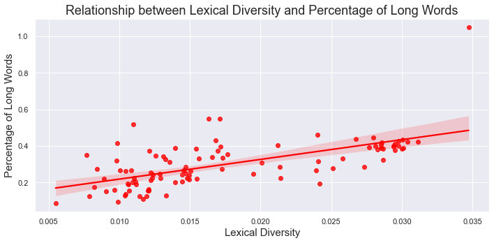

```python
# Regression plot between Percentage of Long Words and Lexical Diversity for the entire dataframe

plt.figure(figsize = (10,5))
fig = sns.regplot(x = data_explore["Lex_Diversity"], y = data_explore["Percent_Long_words"], data = data_explore, color = "red")
plt.xlabel("Lexical Diversity", fontsize = 15)
plt.ylabel("Percentage of Long Words", fontsize = 15)
plt.title("Relationship between Lexical Diversity and Percentage of Long Words", fontsize = 18)
plt.show(fig)
```

- There is a positive correlation between Lexical Diversity and Percentage of Long Words
- As Percentage of Long Words increases, the Lexical Diversity increases too

**Is there any relationship between Number of Unique Words and % of Long Words?**

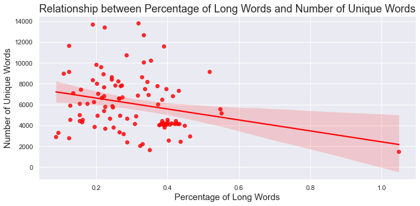

```python
# Regression plot between Percentage of Long Words and Number of Unique Words for the entire dataframe

plt.figure(figsize = (10,5))
fig = sns.regplot(x = data_explore["Percent_Long_words"], y = data_explore["Unique"], data = data_explore, color = "red")
plt.xlabel("Percentage of Long Words", fontsize = 15)
plt.ylabel("Number of Unique Words", fontsize = 15)
plt.title("Relationship between Percentage of Long Words and Number of Unique Words", fontsize = 18)
plt.show(fig)
```

- There is a negative correlation between Number of Unique Words and Percentage of Long Words
- As Percentage of Long Words increases, the Number of Unique Words decreases

### Answers to Question 3

**The Author with the highest % of Long Words: "Charles A. Lee" and the book: "Alaska Indian Dictionary"**

**The Author with the lowest % of Long Words: "Elizabeth Moxon" and the book: "English Housewifery Exemplified"**

**It can be inferred that as the Percentage of Long Words increases, the Lexical Diversity increases too**

**It can also be inferred that as the Percentage of Long Words increases, the Number of Unique Words decreases**

### Question 4: Which Author has written the most number of books?

- This is calculated by counting the number of observations correponding to each Author

### Justification of why this question is interesting

- By finding out which Author has written the most books in the given dataset, more details can be explored about that particular Author as an extension of this assigment by comparing different books of that Author

```python
# The data_df contains the metadata about the text files, same is used to find the number of books by an Author

data_df["Author"].value_counts()         # "value_counts" function counts the number of observations for each Author
```

```
Various                         201
W.W. Jacobs                      52
Roger McGuinn                    30
Anonymous                        30
John Lord                        14
                               ...
Lewis Melville                    1
H. Clay Trumbull                  1
Selected by Frederic Knowles      1
Roy J. Snell                      1
Frances Elliot                    1
Name: Author, Length: 672, dtype: int64
```

- There are 672 different Authors in the entire dataset
- There are 201 books written by "Multiple Authors" under the category "Various"
- There are 30 books for which the Authors are "Anonymous"

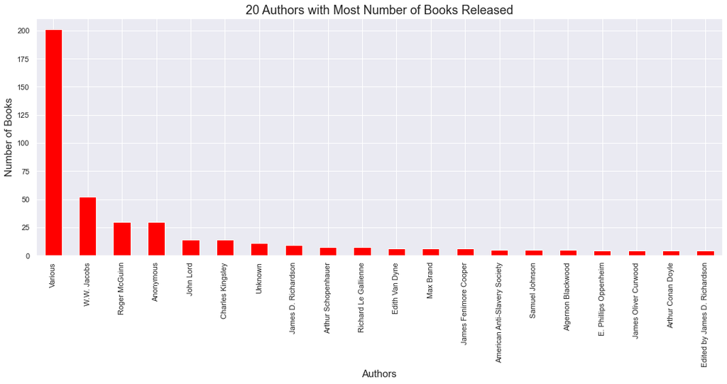

```python
# Plotting a bargraph showing 20 Authors with the most books released

author_count = data_df["Author"].value_counts()[:20]       # Counting only 20 Authors with highest books

plt.figure(figsize = (15,8))
author_count.plot(kind = "bar", color = "red")
plt.title("20 Authors with Most Number of Books Released", fontsize = 18)
plt.xlabel("Authors", fontsize = 15)
plt.ylabel("Number of Books", fontsize = 15)
plt.show()
```

- "Various" category Authors have written the maximum books
- W.W. Jacobs is the individual writer who wrote maximum books

### Answers to Question 4

**As an individual Writer, "W.W. Jacobs" has written the most number of books (52) in the given dataset, however, any of his book were not High in Lexical Diversity, did not have a high % of Long Words, did not have high polarity scores, or did not have most number of Unique POS tags**

**Overall, the Maximum number of books (201) are written by "Multiple Authors" in the given dataset**

### Question 5: Who are the Authors having the most and least number of Unique POS tags in their books?

- The Author and Book are identified using the ID that has the books with the most and least number of Unique POS tags

### Justification of why this question is interesting

- It can be determined which Authors and their books contain how many unique combinations of various kinds of noun, verb, article, adjective, preposition, pronoun, adverb, conjunction, and interjection.
- This also throws a light on the range of vocabulary used in the books by the Authors

```python
# idxmax and idxmin functions are used to find the text files with most and least unique number of POS tags
# These functions are used on column "Unique_POS" containing the number of unique POS tags in the text files in the dataframe

most_unique_POS = data_explore.loc[data_explore["Unique_POS"].idxmax()]
least_unique_POS = data_explore.loc[data_explore["Unique_POS"].idxmin()]
```

#### Book with most number of Unique POS tags

```python
# Calling the variable "most_unique_POS" and showing the File name and number of Unique POS tags it contains

most_unique_POS[["File_name", "Unique_POS"]]
```

```
File_name     10003.txt
Unique_POS           33
Name: 2, dtype: object
```

- The book with File name "10003.txt" has the most number of unique POS tags (33)

```python
# Finding the book with File name "10003.txt" from the "data_df"

print(data_df[(data_df["File_name"] == "10003.txt")][["Title", "Author", "Language"]])
```

```
                                          Title                Author Language
IDs
2    My First Years As A Frenchwoman, 1876-1879  Mary King Waddington  English
```

- The book "My First Years As A Frenchwoman, 1876-1879" written by "Mary King Waddington" in "English" language has the most number of unique POS tags (33)

#### Book with least number of Unique POS tags

```python
# Calling the variable "least_unique_POS" and showing the File name and number of Unique POS tags it contains

least_unique_POS[["File_name", "Unique_POS"]]
```

```
File_name     10040.txt
Unique_POS           24
Name: 36, dtype: object
```

- The book with File name "10040.txt" has the least number of unique POS tags (24)

```python
# Finding the book with File name "10040.txt" from the "data_df"

print(data_df[(data_df["File_name"] == "10040.txt")][["Title", "Author", "Language"]])
```

```
                        Title          Author              Language
IDs
36   Alaska Indian Dictionary  Charles A. Lee  English and Aleutian
```

- The book "Alaska Indian Dictionary" written by "Charles A. Lee" in "English and Aleutian" language has the least number of unique POS tags (24)

### Answers to Question 5

**The Author with the most number of Unique POS tags: "Mary King Waddington" and the book: "My First Years As A Frenchwoman, 1876-1879"**

**The Author with the least number of Unique POS tags: "Charles A. Lee" and the book: "Alaska Indian Dictionary"**

## Section 4: Suggestions

A few recommendations have been made as an extension of this assignment, each accompanied by a reason, with the purpose of improving the dataset with new data and incorporating more advanced modelling techniques and analysis:

### **Suggestion 1.** If more data is available regarding each book:

- **(a) the unique identifier of the book (ISBN code)**
- **(b) the genre of the book and the publication**
- **(c) the reader/user details like age, location**
- **(d) the average book ratings by users**
- **(e) the count of ratings by users**
- **(f) the count of text reviews**

A **Book Recommender System** can be built using Machine Learning techniques where books can be classified based on user needs.  
The recommender system can suggest books to a user by comparing the user-liked or highly rated books with the unrated or low rated books, possibly looking for the most appropriate content to suggest.

There are many datasets corresponding to book reviews and ratings from website called Goodreads(https://www.goodreads.com) that enables users to search through its library of books, authors, ratings, and reviews.

These datasets can be found from any of the following open source databases:

- (a) https://www.kaggle.com
- (b) https://sites.google.com/eng.ucsd.edu/ucsdbookgraph

Book IDs (ISBN) can be fetched by searching through the book titles. Using that, a list of book that the user likes can be created to recommend the book that the user has not read yet and might like based on all of these factors in the dataset.

A table can be created to map out the users who did not read a book. The program can request the books ID from the user before internally calculating its correlation with the other books in the dataset. Then the correlation scores can be used to determine which book should be recommended.

The program can also select the users, books, and associated features to present the recommendation using multiclassification or regression techniques. Recommendation can be based on choosing the best rated books as determined by the model.

Recommendation can also be done by finding all of the users who liked the same book as the user and finding all other books they liked, to use those as recommendations.

Referred from:

- **(a)** https://www.youtube.com/watch?v=x-alwfgQ-cY
- **(b)** https://medium.com/@amitdlmlai/book-recommendation-system-61bf9284f659
- **(c)** https://github.com/ashima96/Book-Recommendation-System/blob/master/BRS.ipynb

### **Suggestion 2.** Using spaCy library, **Shallow Parsing** and **Dependency Parsing** can be done.

The process of breaking down a sentence into its simplest components (tokens such as words) and grouping them into higher-level phrases is known as Shallow Parsing or Chunking. It is a method of obtaining short phrases meaningfully from sentences that have been identified as parts of speech. Words comprises of chunks, and the POS tags are used to define the types of words.

Shallow Parsing employs POS tags as inputs and outputs chunks, building on top of POS tagging. There is a standard set of chunk tags, similar to POS tags (such as Noun Phrase (NP) or Verb Phrase (VP)). This is a crucial step when information like location or a person's name needs to be extracted from text in a process known as Named Entity Recognition (NER).

Dependency Parsing is the process of analysing a sentence's grammatical structure to identify related words and the nature of their relationships. Every relationship consists of a head and a dependent that influences the head. Each relationship is given a classification based on the nature of the dependency between the head and dependent. The development of information extraction systems, Natural Language Understanding systems, and text pre-processing for deep learning systems can all incorporate this technique.

These two parsing techniques can be built as an extension to POS tagging done in this assignment.

Referred from:

- **(a)** https://towardsdatascience.com/natural-language-processing-dependency-parsing-cf094bbbe3f7
- **(b)** https://www.youtube.com/watch?v=kyU1yZab4yA
- **(c)** https://www.tutorialspoint.com/natural_language_toolkit/natural_language_toolkit_parsing.htm
- **(d)** https://towardsdatascience.com/a-practitioners-guide-to-natural-language-processing-part-i-processing-understanding-text-9f4abfd13e72

### **Suggestion 3.** **Named Entity Recognition** can be done as an extension of this project.

There are special terms that represent particular entities that are more informative and have a specific context in any text. Named entities are phrases that reflect real-world items like people, locations, organisations, and so forth, which are identified by proper names.

Named entity recognition (NER), can be used for identifying and classifying named entities into a variety of predetermined categories as an advancement to this assignment.

The tokens or chunks extracted during Shallow Parsing can be searched against a knowledge base, which is an ontology consisting of words, their meanings, and the relationships among these words.

Referred from:

- **(a)** https://towardsdatascience.com/a-practitioners-guide-to-natural-language-processing-part-i-processing-understanding-text-9f4abfd13e72
- **(b)** https://www.youtube.com/watch?v=6djUJyljhq8
- **(c)** https://github.com/WomenWhoCode/WWCodeDataScience/blob/master/Intro_to_NLP/2_NLP_DeepDive1.ipynb

### **Suggestion 4.**

The books can be **grouped by the Authors** and then books can be analysed in NLP mannner for different Authors individually to find patters and relationship to better comprehend the data.

Since the book **"Alaska Indian Dictionary"** had the **highest Lexical Diversity, highest % of Long Words, and least number of Unqiue POS tags**, this book can be explored further individually to extract some more useful insights.

Also, since **"W.W. Jacobs"** has written the most number of books as an individual writers, this writer's books can be compared to see if there are any similarities or differences.

There are maximum books under the category "Various" Authors. If more information can be gathered for this category, a detailed analysis can be done which can reveal information about why this category has written the most number of books.

## Section 5: Bibliography

Amit (2017) Book Recommendation System . Available: https://medium.com/@amitdlmlai/book-recommendation-system-61bf9284f659 [Accessed: 7 December 2022].

Ananda, T. (2020a) Chunking Partial Shallow Parsing Chinking. Available: https://www.youtube.com/watch?v=kyU1yZab4yA [Accessed: 9 December 2022].

Ananda, T. (2020b) Named Entity Recognition NER. Available: https://www.youtube.com/watch?v=6djUJyljhq8 [Accessed: 9 December 2022].

Ashima (2021) Book Recommendation System. Available: https://github.com/ashima96/Book-Recommendation-System/blob/master/BRS.ipynb [Accessed: 6 December 2022].

Beri, A. (2020) SENTIMENTAL ANALYSIS USING VADER. Available: https://towardsdatascience.com/sentimental-analysis-using-vader-a3415fef7664 [Accessed: 6 December 2022].

Bird, S., Klein, E. and Loper, E. Natural Language Processing with Python – Analyzing Text with the Natural Language Toolkit.

Çöltekin, Ç (2018) Statistical Natural Language Processing. University of Tübingen: Available: https://snlp2018.github.io/slides/pos-tagging-handout.pdf [Accessed: 6 December 2022].

czakon, j. (2020a) 1.3-top_stopwords_barchart. Available: https://app.neptune.ai/neptune-ai/eda-nlp-tools/n/1-3-top-stopwords-barchart-b953763c-3fea-4331-bff0-429411793e5f/5c0fca05-ba07-4564-a02e-c44b08bfb8cb [Accessed: 5 December 2022].

czakon, j. (2020b) 1.4-top_non_stopwords_barchart. Available: https://app.neptune.ai/neptune-ai/eda-nlp-tools/n/1-4-top-non-stopwords-barchart-36267acc-a418-4a5f-a3ba-67a3b51dde12/b57bc536-8cec-46a7-918c-60fba6f2c83d [Accessed: 5 December 2022].

Dataquest (2022) Build A Book Recommendation System With Machine Learning. Available: https://www.youtube.com/watch?v=x-alwfgQ-cY [Accessed: 8 December 2022].

Fogelberg, H. upload folder to Jupyter Notebook. Available: https://gist.github.com/hfogelberg/8d0e0c0c25aa64947c4dbb86f6ad2673 [Accessed: 4 December 2022].

freeCodeCamp.org (2018) Natural Language Processing (NLP) Tutorial with Python & NLTK. Available: https://www.youtube.com/watch?v=X2vAabgKiuM [Accessed: 5 December 2022].

Frost, J. Bimodal Distribution: Definition, Examples & Analysis. Available: https://statisticsbyjim.com/basics/bimodal-distribution/ [Accessed: 4 December 2022].

Garg, S. (2021) The Gutenberg Project: Natural Language Processing. Available: https://medium.com/nerd-for-tech/the-gutenberg-project-natural-language-processing-1fc77616b298 [Accessed: 3 December 2022].

GeeksforGeeks (a) Python – seaborn.regplot() method. Available: https://www.geeksforgeeks.org/python-seaborn-regplot-method/ [Accessed: 4 December 2022].

GeeksforGeeks (b) Python | Pandas DataFrame.set_index(). Available: https://www.geeksforgeeks.org/python-pandas-dataframe-set_index/ [Accessed: 4 December 2022].

GeeksforGeeks (2021) Histograms and Density Plots in Python. Available: https://www.geeksforgeeks.org/histograms-and-density-plots-in-python/?ref=gcse [Accessed: 4 December 2022].

GeeksforGeeks (2022a) Applying Lambda functions to Pandas Dataframe . Available: https://www.geeksforgeeks.org/applying-lambda-functions-to-pandas-dataframe/ [Accessed: 4 December 2022].

GeeksforGeeks (2022b) Pandas GroupBy – Count the occurrences of each combination. Available: https://www.geeksforgeeks.org/pandas-groupby-count-the-occurrences-of-each-combination/ [Accessed: 4 December 2022].

Glen, S. Skewed Distribution: Definition, Examples. Available: https://www.statisticshowto.com/probability-and-statistics/skewed-distribution/ [Accessed: 4 December 2022].

Huang, M. (2019) Natural Language Processing for Project Gutenberg. Available: https://github.com/MengyaoHuang/Data-Manipulation-and-Analysis/blob/master/Natural%20Language%20Processing%20for%20Project%20Gutenberg.ipynb [Accessed: 4 December 2022].

Jain, Y. (2017) Text cleaning (using Regex) [Python]. Available: https://medium.com/@yashj302/text-cleaning-using-regex-python-f1dded1ac5bd [Accessed: 4 December 2022].

Jaiswal, S. (2021) Natural Language Processing — Dependency Parsing. Available: https://towardsdatascience.com/natural-language-processing-dependency-parsing-cf094bbbe3f7 [Accessed: 9 December 2022].

Koehler, J. (2018) Webscraping Text with Python and Intro to Natural Language Processing with NLTK. Available: https://www.youtube.com/watch?v=q7AM9QjCRrI&list=PLUCTTwyv9AdUYtNeV5w-2xMX5O9cCcfkB&index=5 [Accessed: 5 December 2022].

pandas.pydata.org (a) pandas.DataFrame.apply. Available: https://pandas.pydata.org/pandas-docs/stable/reference/api/pandas.DataFrame.apply.html [Accessed: 4 December 2022].

pandas.pydata.org (b) pandas.DataFrame.iloc. Available: https://pandas.pydata.org/docs/reference/api/pandas.DataFrame.iloc.html [Accessed: 4 December 2022].

pandas.pydata.org (c) pandas.DataFrame.loc. Available: https://pandas.pydata.org/docs/reference/api/pandas.DataFrame.loc.html [Accessed: 4 December 2022].

pythonspot NLTK stop words . Available: https://pythonspot.com/nltk-stop-words/#:~:text=Stop%20words%20are%20words%20that,most%20common%20words%20in%20data. [Accessed: 4 December 2022].

Ramos, L.P. Using the Python zip() Function for Parallel Iteration. Available: https://realpython.com/python-zip-function/ [Accessed: 5 December 2022].

Rishi, R.K. (2021) Matplotlib – Make a Frequency histogram from a list with tuple elements in Python. Available: https://www.tutorialspoint.com/matplotlib-make-a-frequency-histogram-from-a-list-with-tuple-elements-in-python [Accessed: 5 December 2022].

Sarkar, D. (2018) A Practitioner's Guide to Natural Language Processing (Part I) — Processing & Understanding Text. Available: https://towardsdatascience.com/a-practitioners-guide-to-natural-language-processing-part-i-processing-understanding-text-9f4abfd13e72 [Accessed: 6 December 2022].

Shahul, E.S. (2022) Exploratory Data Analysis for Natural Language Processing: A Complete Guide to Python Tools. Available: https://neptune.ai/blog/exploratory-data-analysis-natural-language-processing-tools [Accessed: 5 December 2022].

stackoverflow (a) Cleaning Text with python and re. Available: https://stackoverflow.com/questions/55187374/cleaning-text-with-python-and-re [Accessed: 4 December 2022].

stackoverflow (b) Function that calculates the total number of unique words in a textfile. Available: https://stackoverflow.com/questions/53311151/function-that-calculates-the-total-number-of-unique-words-in-a-textfile [Accessed: 4 December 2022].

tutorialspoint Python - Remove Stopwords. Available: https://www.tutorialspoint.com/python_text_processing/python_remove_stopwords.htm#:~:text=Stopwords%20are%20the%20English%20words,this%20in%20corpus%20named%20corpus. [Accessed: 5 December 2022].

tutorialspoint (2022) Natural Language Toolkit - Parsing. Available: https://www.tutorialspoint.com/natural_language_toolkit/natural_language_toolkit_parsing.htm [Accessed: 6 December 2022].

w3schools (a) Pandas DataFrame idxmax() Method. Available: https://www.w3schools.com/python/pandas/ref_df_idxmax.asp [Accessed: 6 December 2022].

w3schools (b) Python - List Comprehension. Available: https://www.w3schools.com/python/python_lists_comprehension.asp [Accessed: 4 December 2022].

WomenWhoCode (2020) Introduction to Natural Language Processing. Available: https://github.com/WomenWhoCode/WWCodeDataScience/tree/master/Intro_to_NLP [Accessed: 6 December 2022].